# Modelowanie zużycia paliwa — regresja z tidymodels

Regresja liniowa, LASSO, drzewo CART i XGBoost — od czyszczenia po SHAP

25 May 2026

# 1 Wprowadzenie

## 1.1 O czym jest ten dokument

Ten dokument prowadzi przez **kompletną ścieżkę modelowania regresyjnego** - od wczytania surowego pliku Excel z danymi o samochodach, przez czyszczenie i inżynierię cech, po budowę, strojenie i porównanie czterech modeli predykcyjnych. Całość jest realizowana w ekosystemie **tidymodels** - nowoczesnym frameworku do modelowania w R.

Dokument łączy trzy warstwy:

- **warstwa analityczna** - każdy krok jest wykonany i zinterpretowany w kontekście problemu predykcyjnego,
- **warstwa programistyczna** - kod wykorzystuje pipeline’y tidymodels (recipes → workflows → tune), które zapewniają powtarzalność i brak wycieku danych,
- **warstwa dydaktyczna** - bloki oznaczone **📖 Przypomnienie teoretyczne** wyjaśniają statystyczne „dlaczego” za każdą decyzją.

## 1.2 Czego dotyczy analiza

Pytanie predykcyjne: **czy na podstawie parametrów technicznych samochodu (pojemność, moc, masa, liczba cylindrów, przyspieszenie, rok produkcji, pochodzenie) można przewidzieć jego zużycie paliwa?**

Porównamy cztery podejścia: **regresję liniową** (OLS), **LASSO** (regularyzacja L1), **drzewo regresyjne** (CART) i **XGBoost** (gradient boosting). Każdy model zostanie oceniony na zbiorze walidacyjnym (v-fold CV), a najlepszy - na odłożonym zbiorze testowym.

## 1.3 Ścieżka analizy - mapa dokumentu

1. **Czym jest tidymodels?** → krótkie wprowadzenie do frameworka
2. **Wczytanie i przegląd danych** → zrozumienie struktury
3. **Eksploracja (EDA)** → rozkłady, korelacje, outlier’y
4. **Podział train / test** → `rsample::initial_split()`
5. **Preprocessing z recipes** → winsoryzacja, kodowanie, standaryzacja
6. **Regresja liniowa (OLS)** → model bazowy
7. **Regresja LASSO** → regularyzacja i selekcja zmiennych
8. **Drzewo regresyjne (CART)** → model nieparametryczny + strojenie
9. **XGBoost** → gradient boosting + strojenie siatki
10. **Porównanie modeli** → metryki CV obok siebie
11. **Ewaluacja na zbiorze testowym** → ocena generalizacji
12. **Interpretowalność** → ważność zmiennych i SHAP

## 1.4 Konwencje użyte w dokumencie

- **📖 Przypomnienie teoretyczne** - zwięzłe wprowadzenie przed krokiem analitycznym.
- **⚠️ Pułapka** — typowy błąd, którego warto unikać.
- Sekcje oznaczone **(*)** są opcjonalne.

# 2 Czym jest tidymodels?

> **📖 Wprowadzenie do ekosystemu tidymodels**

> **tidymodels** to zestaw pakietów R stworzonych przez zespół RStudio / Posit, który ujednolica i upraszcza cały proces modelowania statystycznego i uczenia maszynowego. Analogicznie do tego, jak **tidyverse** ujednolica manipulację danymi, tidymodels ujednolica modelowanie.

> Kluczowe pakiety:

> | Pakiet | Rola |
> | --- | --- |
> | **rsample** | podział danych (train/test, v-fold CV) |
> | **recipes** | preprocessing: transformacje, kodowanie, standaryzacja |
> | **parsnip** | ujednolicony interfejs do modeli (lm, glmnet, xgboost, rpart…) |
> | **workflows** | łączenie recipe + model w jeden pipeline |
> | **tune** | strojenie hiperparametrów (grid search, Bayesian) |
> | **yardstick** | metryki jakości (RMSE, MAE, R², MAPE…) |
> | **workflowsets** | porównanie wielu pipeline’ów naraz |

> **Dlaczego tidymodels, a nie „gołe” pakiety?**
> 1. **Brak wycieku danych** - preprocessing (np. standaryzacja, imputacja) jest definiowany w `recipe`, ale **obliczany tylko na zbiorze treningowym** i automatycznie stosowany do testowego. W ręcznym podejściu łatwo popełnić błąd i policzyć średnią na całym zbiorze.
> 2. **Jednolity interfejs** - zmiana modelu z regresji liniowej na XGBoost to zmiana jednej linijki (`set_engine()`), reszta pipeline’u pozostaje bez zmian.
> 3. **Powtarzalność** - cały przepis (recipe + model + tuning) jest obiektem, który można zapisać, odtworzyć i wersjonować.

> **Schemat pracy w tidymodels:**

> ```
> dane → split (rsample)
>          ├── training → recipe (preprocessing)
>          │                 ↓
>          │              workflow (recipe + model)
>          │                 ↓
>          │              tune / fit (v-fold CV)
>          │                 ↓
>          │              select_best → finalize
>          └── testing  → last_fit → metryki końcowe
> ```

# 3 Przygotowanie środowiska

## 3.1 Wymagane pakiety

```r
packages <- c(
  "tidyverse",       # manipulacja i wizualizacja danych
  "tidymodels",      # rsample, recipes, parsnip, workflows, tune, yardstick
  "readxl",          # wczytywanie plików Excel
  "janitor",         # porządkowanie nazw kolumn
  "skimr",           # szybki przegląd statystyczny
  "corrplot",        # wizualizacja korelacji
  "vip",             # ważność zmiennych (Variable Importance Plots)
  "patchwork",       # łączenie wykresów ggplot
  "knitr",           # kable()
  "glmnet",          # silnik dla LASSO
  "rpart",           # silnik dla drzew CART
  "rpart.plot",      # wizualizacja drzew
  "xgboost",         # silnik dla XGBoost
  "shapviz",         # SHAP
  "kknn"             # silnik dla KNN
)

missing_packages <- packages[
  !vapply(packages, requireNamespace, logical(1), quietly = TRUE)
]

if (length(missing_packages) > 0) {
  install.packages(missing_packages)
} else {
  message("Wszystkie wymagane pakiety są już zainstalowane.")
}
```

## 3.2 Wczytanie bibliotek

```r
library(tidyverse)     # dplyr + ggplot2 + tidyr + purrr
library(tidymodels)    # cały ekosystem tidymodels
library(readxl)        # read_excel()
library(janitor)       # clean_names()
library(skimr)         # skim()
library(corrplot)      # corrplot()
library(vip)           # vip(), vi()
library(patchwork)     # operator + do łączenia ggplotów
library(knitr)         # kable()
library(rpart.plot)    # rpart.plot()
library(shapviz)       # SHAP
library(kknn)          # KNN

tidymodels_prefer()    # rozwiązuje konflikty nazw na korzyść tidymodels
set.seed(42)           # powtarzalność wyników
```

## 3.3 Własny krok `recipes` do winsoryzacji IQR

W tym materiale stosujemy winsoryzację, ale robimy to jako pełnoprawny krok `recipes`. Dzięki temu granice przycinania są wyznaczane w `prep()` wyłącznie na danych uczących, a następnie te same granice są stosowane w `bake()` do danych walidacyjnych lub testowych. W walidacji krzyżowej oznacza to, że granice są estymowane osobno w każdym foldzie, wyłącznie na części treningowej danego folda. **Szczegóły implementacyjne tego kroku można potraktować jako materiał dodatkowy**

Nie musisz teraz rozumieć całej implementacji tego kroku. Wystarczy wiedzieć, że definiujemy własny krok `recipes`, który będzie potem działał tak jak standardowe kroki: `step_dummy()`, `step_normalize()` czy `step_zv()`.

```r
step_winsorize_iqr <- function(recipe,
                               ...,
                               role = NA,
                               trained = FALSE,
                               limits = NULL,
                               multiplier = 1.5,
                               skip = FALSE,
                               id = recipes::rand_id("winsorize_iqr")) {
  recipes::add_step(
    recipe,
    step_winsorize_iqr_new(
      terms = rlang::enquos(...),
      role = role,
      trained = trained,
      limits = limits,
      multiplier = multiplier,
      skip = skip,
      id = id
    )
  )
}

step_winsorize_iqr_new <- function(terms,
                                   role,
                                   trained,
                                   limits,
                                   multiplier,
                                   skip,
                                   id) {
  recipes::step(
    subclass = "winsorize_iqr",
    terms = terms,
    role = role,
    trained = trained,
    limits = limits,
    multiplier = multiplier,
    skip = skip,
    id = id
  )
}

prep.step_winsorize_iqr <- function(x, training, info = NULL, ...) {
  col_names <- names(recipes::recipes_eval_select(x$terms, training, info))

  recipes::check_type(training[, col_names], types = c("double", "integer"))

  limits <- list()

  for (col_name in col_names) {
    values <- training[[col_name]]

    if (all(is.na(values))) {
      limits[[col_name]] <- c(lower = -Inf, upper = Inf)
    } else {
      q <- stats::quantile(values,
                           probs = c(0.25, 0.75),
                           na.rm = TRUE,
                           names = FALSE)
      iqr_value <- q[2] - q[1]

      limits[[col_name]] <- c(
        lower = q[1] - x$multiplier * iqr_value,
        upper = q[2] + x$multiplier * iqr_value
      )
    }
  }

  step_winsorize_iqr_new(
    terms = x$terms,
    role = x$role,
    trained = TRUE,
    limits = limits,
    multiplier = x$multiplier,
    skip = x$skip,
    id = x$id
  )
}

bake.step_winsorize_iqr <- function(object, new_data, ...) {
  col_names <- names(object$limits)
  recipes::check_new_data(col_names, object, new_data)

  for (col_name in col_names) {
    lower <- object$limits[[col_name]][["lower"]]
    upper <- object$limits[[col_name]][["upper"]]

    new_data[[col_name]] <- pmin(
      pmax(new_data[[col_name]], lower),
      upper
    )
  }

  new_data
}

print.step_winsorize_iqr <- function(x,
                                     width = max(20, options()$width - 35),
                                     ...) {
  recipes::print_step(
    tr_obj = names(x$limits),
    untr_obj = x$terms,
    trained = x$trained,
    title = "Winsoryzacja IQR dla ",
    width = width
  )
  invisible(x)
}

tidy.step_winsorize_iqr <- function(x, ...) {
  if (recipes::is_trained(x)) {
    if (length(x$limits) == 0) {
      out <- tibble(
        terms = character(),
        lower = numeric(),
        upper = numeric()
      )
    } else {
      out <- purrr::map_dfr(
        names(x$limits),
        ~ tibble(
          terms = .x,
          lower = unname(x$limits[[.x]][["lower"]]),
          upper = unname(x$limits[[.x]][["upper"]])
        )
      )
    }
  } else {
    out <- tibble(
      terms = recipes::sel2char(x$terms),
      lower = rlang::na_dbl,
      upper = rlang::na_dbl
    )
  }

  out$id <- x$id
  out
}
```

W dalszej części użyjemy pomocniczej funkcji `step_winsorize_iqr()`. Jest to własny krok `recipes`, który działa analogicznie do innych kroków preprocessingu: podczas `prep()` wyznacza granice winsoryzacji na danych treningowych, a podczas `bake()` stosuje te same granice do danych walidacyjnych lub testowych. Dzięki temu winsoryzacja nie powoduje wycieku danych.

> **⚠️ Pułapka:** Funkcja `tidymodels_prefer()` rozwiązuje konflikty nazw (np. `yardstick::spec()` vs `readr::spec()`). Bez niej mogą pojawić się trudne do zdiagnozowania błędy.

# 4 Wczytanie i pierwszy przegląd danych

## 4.1 Opis zbioru danych

Zbiór **Auto MPG** zawiera dane o 392 samochodach osobowych z lat 70. i 80. XX wieku. Zmienne:

| Zmienna | Opis | Skala |
| --- | --- | --- |
| `zuzycie` | zużycie paliwa (l/100 km) | ilorazowa |
| `cylindry` | liczba cylindrów | porządkowa |
| `pojemnosc` | pojemność silnika (cm³) | ilorazowa |
| `moc` | moc silnika (KM) | ilorazowa |
| `masa` | masa pojazdu (kg) | ilorazowa |
| `przysp` | czas przyspieszenia 0–60 mph (s) | ilorazowa |
| `rok` | rok produkcji (ostatnie 2 cyfry) | przedziałowa |
| `pochodzenie` | kontynent pochodzenia (Ameryka/Azja/Europa) | nominalna |
| `nazwa` | nazwa samochodu | identyfikator |

```r
df_raw <- read_excel("auto-mpg.xlsx")
```

W tym przypadku oryginalne nazwy kolumn (`zuzycie`, `cylindry`, `pojemnosc`, `moc`, `masa`, `przysp`, `rok`, `pochodzenie`, `nazwa`) są już stosunkowo czyste - nie zawierają spacji ani nawiasów. `clean_names()` upewnia się jednak, że format jest jednolicie **snake_case** i nie pojawią się niespodzianki (np. niewidoczne znaki czy wielkie litery). Dodatkowa kolumna `case_id` numeruje obserwacje - przydaje się do identyfikacji konkretnych samochodów w późniejszych krokach diagnostycznych.

```r
df <- df_raw %>%
  clean_names() %>%
  mutate(case_id = row_number(), .before = 1)

names(df)
```

```
##  [1] "case_id"     "zuzycie"     "cylindry"    "pojemnosc"   "moc"
##  [6] "masa"        "przysp"      "rok"         "pochodzenie" "nazwa"
```

## 4.2 Szybki przegląd

```r
dim(df)
```

```
## [1] 392  10
```

```r
glimpse(df)
```

```
## Rows: 392
## Columns: 10
## $ case_id     <int> 1, 2, 3, 4, 5, 6, 7, 8, 9, 10, 11, 12, 13, 14, 15, 16, 17,…
## $ zuzycie     <dbl> 13.068, 15.681, 13.068, 14.701, 13.837, 15.681, 16.801, 16…
## $ cylindry    <dbl> 8, 8, 8, 8, 8, 8, 8, 8, 8, 8, 8, 8, 8, 8, 4, 6, 6, 6, 4, 4…
## $ pojemnosc   <dbl> 5033, 5738, 5213, 4984, 4951, 7033, 7443, 7213, 7459, 6393…
## $ moc         <dbl> 130, 165, 150, 150, 140, 198, 220, 215, 225, 190, 170, 160…
## $ masa        <dbl> 1592.9, 1678.8, 1562.0, 1560.6, 1567.9, 1973.4, 1979.3, 19…
## $ przysp      <dbl> 12.0, 11.5, 11.0, 12.0, 10.5, 10.0, 9.0, 8.5, 10.0, 8.5, 1…
## $ rok         <dbl> 70, 70, 70, 70, 70, 70, 70, 70, 70, 70, 70, 70, 70, 70, 70…
## $ pochodzenie <chr> "Ameryka", "Ameryka", "Ameryka", "Ameryka", "Ameryka", "Am…
## $ nazwa       <chr> "chevrolet chevelle malibu", "buick skylark 320", "plymout…
```

```r
skim(df)
```

Data summary

| Name | df |
| --- | --- |
| Number of rows | 392 |
| Number of columns | 10 |
| _______________________ |  |
| Column type frequency: |  |
| character | 2 |
| numeric | 8 |
| ________________________ |  |
| Group variables | None |

**Variable type: character**

| skim_variable | n_missing | complete_rate | min | max | empty | n_unique | whitespace |
| --- | --- | --- | --- | --- | --- | --- | --- |
| pochodzenie | 0 | 1 | 4 | 7 | 0 | 3 | 0 |
| nazwa | 0 | 1 | 6 | 36 | 0 | 301 | 0 |

**Variable type: numeric**

| skim_variable | n_missing | complete_rate | mean | sd | p0 | p25 | p50 | p75 | p100 | hist |
| --- | --- | --- | --- | --- | --- | --- | --- | --- | --- | --- |
| case_id | 0 | 1 | 196.50 | 113.30 | 1.00 | 98.75 | 196.50 | 294.25 | 392.00 | ▇▇▇▇▇ |
| zuzycie | 0 | 1 | 11.25 | 3.91 | 5.05 | 8.11 | 10.34 | 13.84 | 26.14 | ▇▇▃▂▁ |
| cylindry | 0 | 1 | 5.47 | 1.71 | 3.00 | 4.00 | 4.00 | 8.00 | 8.00 | ▇▁▃▁▅ |
| pojemnosc | 0 | 1 | 3187.08 | 1715.48 | 1114.75 | 1721.31 | 2475.41 | 4520.49 | 7459.02 | ▇▂▂▃▁ |
| moc | 0 | 1 | 104.47 | 38.49 | 46.00 | 75.00 | 93.50 | 126.00 | 230.00 | ▆▇▃▁▁ |
| masa | 0 | 1 | 1353.61 | 386.14 | 733.27 | 1011.60 | 1274.47 | 1643.27 | 2336.64 | ▇▇▅▅▂ |
| przysp | 0 | 1 | 15.54 | 2.76 | 8.00 | 13.78 | 15.50 | 17.02 | 24.80 | ▁▆▇▂▁ |
| rok | 0 | 1 | 75.98 | 3.68 | 70.00 | 73.00 | 76.00 | 79.00 | 82.00 | ▇▆▇▆▇ |

## 4.3 Ustalenie ról zmiennych

```r
id_vars     <- c("case_id", "nazwa")
target_var  <- "zuzycie"
cat_preds   <- "pochodzenie"
num_preds   <- setdiff(names(df), c(id_vars, target_var, cat_preds))

cat("Zmienna zależna (Y):", target_var, "\n")
```

```
## Zmienna zależna (Y): zuzycie
```

```r
cat("Predyktory ilościowe:", paste(num_preds, collapse = ", "), "\n")
```

```
## Predyktory ilościowe: cylindry, pojemnosc, moc, masa, przysp, rok
```

```r
cat("Predyktory jakościowe:", cat_preds, "\n")
```

```
## Predyktory jakościowe: pochodzenie
```

Zamieniamy `pochodzenie` z typu `character` na **factor** - R traktuje go wtedy jako zmienną jakościową z ustalonymi poziomami (Ameryka, Azja, Europa). Dzięki temu `recipe` automatycznie rozpozna tę kolumnę jako kategoryczną i zastosuje odpowiednie kodowanie (`step_dummy`), a wykresy grupujące dostaną poprawną legendę bez dodatkowej konfiguracji.

```r
df <- df %>%
  mutate(pochodzenie = factor(pochodzenie))
```

# 5 Eksploracyjna analiza danych (EDA)

## 5.1 Raport braków danych

```r
tibble(
  variable    = names(df),
  n_missing   = map_int(df, ~ sum(is.na(.x))),
  pct_missing = map_dbl(df, ~ round(mean(is.na(.x)) * 100, 2))
) %>%
  filter(n_missing > 0)
```

| variable | n_missing | pct_missing |
| --- | --- | --- |

W tym zbiorze **nie ma braków danych** - nie musimy imputować. To wyjątkowa sytuacja; w praktyce pierwszy krok po EDA to niemal zawsze obsługa NA.

## 5.2 Rozkład zmiennej zależnej

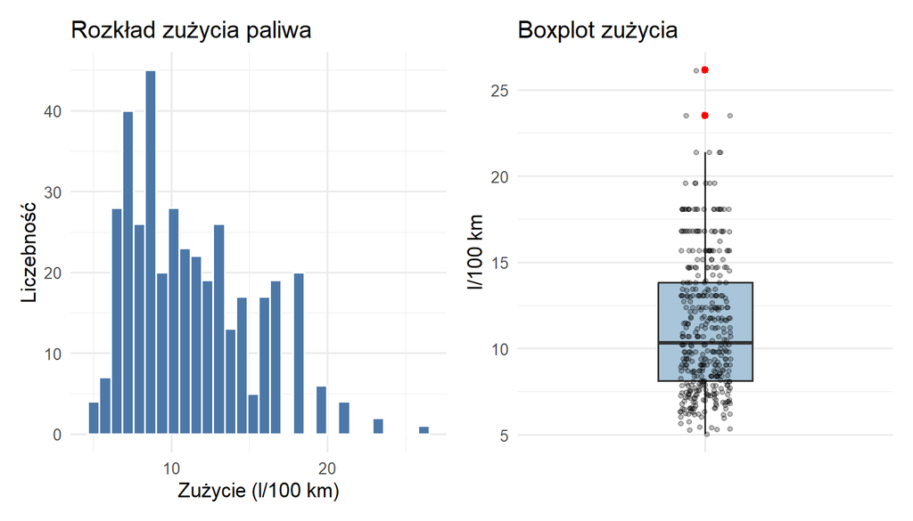

```r
p_hist <- ggplot(df, aes(x = zuzycie)) +
  geom_histogram(bins = 30, fill = "#4C78A8", colour = "white") +
  labs(title = "Rozkład zużycia paliwa", x = "Zużycie (l/100 km)",
       y = "Liczebność") +
  theme_minimal()

p_box <- ggplot(df, aes(y = zuzycie, x = "")) +
  geom_boxplot(width = 0.3, fill = "#A8C5DA", outlier.colour = "red") +
  geom_jitter(width = 0.08, alpha = 0.25, size = 1) +
  labs(title = "Boxplot zużycia", x = NULL, y = "l/100 km") +
  theme_minimal()

p_hist + p_box
```

Rozkład jest **prawostronnie skośny** - wiele aut o niskim zużyciu, kilka „paliwożernych” modeli. Transformacja logarytmiczna mogłaby pomóc regresji liniowej (stabilizacja wariancji reszt). Modele drzewiaste nie wymagają takiej transformacji.

## 5.3 Rozkłady predyktorów ilościowych

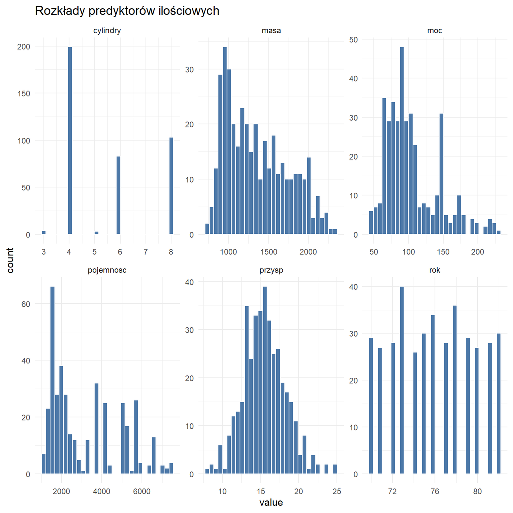

```r
df %>%
  dplyr::select(all_of(num_preds)) %>%
  pivot_longer(everything(), names_to = "variable", values_to = "value") %>%
  ggplot(aes(x = value)) +
  geom_histogram(bins = 30, fill = "#4C78A8", colour = "white") +
  facet_wrap(~ variable, scales = "free", ncol = 3) +
  labs(title = "Rozkłady predyktorów ilościowych") +
  theme_minimal(base_size = 10)
```

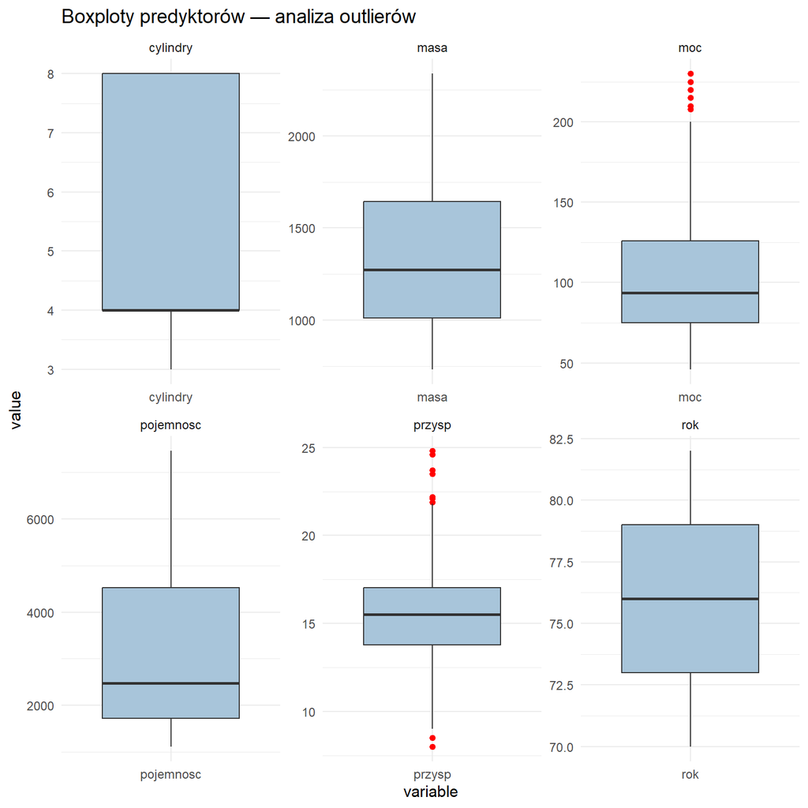

```r
df %>%
  dplyr::select(all_of(num_preds)) %>%
  pivot_longer(everything(), names_to = "variable", values_to = "value") %>%
  ggplot(aes(x = variable, y = value)) +
  geom_boxplot(fill = "#A8C5DA", outlier.colour = "red") +
  facet_wrap(~ variable, scales = "free", ncol = 3) +
  labs(title = "Boxploty predyktorów — analiza outlierów") +
  theme_minimal(base_size = 10)
```

## 5.4 Rozkład zmiennej jakościowej

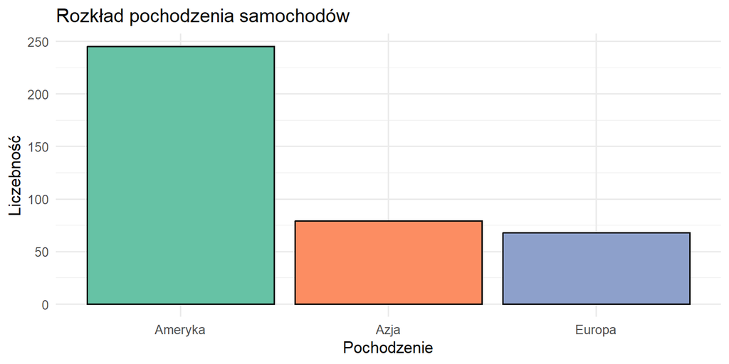

```r
df %>%
  count(pochodzenie) %>%
  ggplot(aes(x = reorder(pochodzenie, -n), y = n, fill = pochodzenie)) +
  geom_col(show.legend = FALSE, colour = "black") +
  scale_fill_brewer(palette = "Set2") +
  labs(title = "Rozkład pochodzenia samochodów",
       x = "Pochodzenie", y = "Liczebność") +
  theme_minimal()
```

## 5.5 Korelacje między zmiennymi ilościowymi

W tym przykładzie do oceny zależności pomiędzy zmiennymi wykorzystujemy korelację Spearmana, a nie korelację Pearsona. Korelacja Spearmana jest oparta na rangach, dlatego jest mniej wrażliwa na wartości odstające i nie wymaga tak silnych założeń dotyczących rozkładu zmiennych. Dodatkowo pozwala wykrywać zależności monotoniczne, czyli takie, w których wraz ze wzrostem jednej zmiennej druga ma tendencję do wzrostu lub spadku, nawet jeśli zależność nie jest idealnie liniowa. Jest to szczególnie przydatne na etapie eksploracyjnej analizy danych, gdy nie mamy jeszcze pewności, jaki charakter mają relacje pomiędzy zmiennymi.

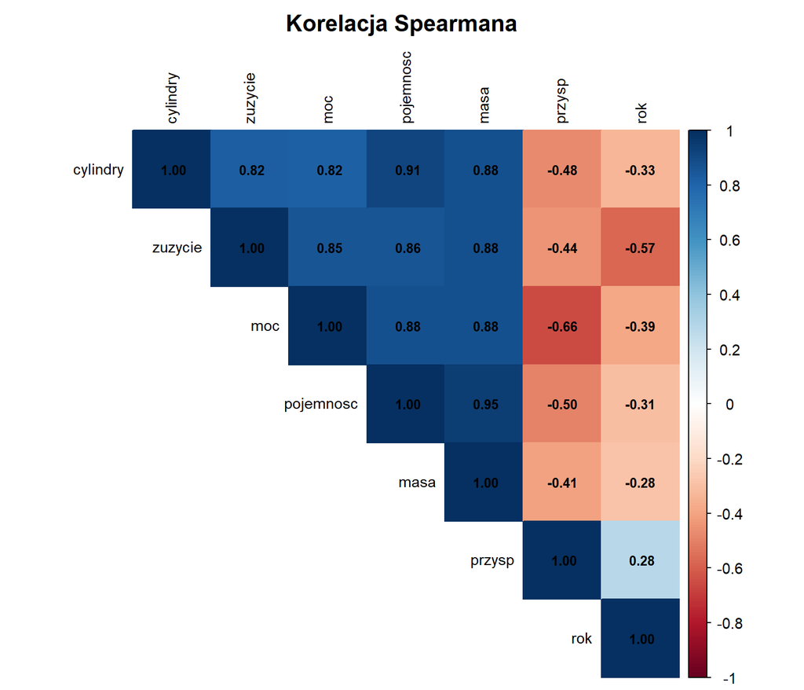

```r
cor_mat <- cor(df %>% dplyr::select(all_of(c(target_var, num_preds))),
               method = "spearman")

corrplot(cor_mat,
         method      = "color",
         type        = "upper",
         order       = "hclust",
         addCoef.col = "black",
         number.cex  = 0.7,
         tl.cex      = 0.8,
         tl.col      = "black",
         title       = "Korelacja Spearmana",
         mar         = c(0, 0, 2, 0))
```

⚠️ **Pułapka - współliniowość:** zmienne `pojemnosc`, `cylindry`, `masa` i `moc` są silnie wzajemnie skorelowane, czyli niosą bardzo podobną informację o samochodzie. W regresji liniowej może to powodować niestabilność współczynników oraz tzw. **odwrócenie znaków** - na przykład zmienna, która analizowana osobno wydaje się zwiększać zużycie paliwa, w modelu wielowymiarowym może otrzymać współczynnik ujemny, bo model „rozlicza” jej efekt po uwzględnieniu innych, podobnych zmiennych. Nie musi to oznaczać realnej zależności przyczynowej, tylko problem z jednoznacznym oddzieleniem wpływu mocno powiązanych predyktorów. LASSO częściowo rozwiązuje ten problem automatycznie, ponieważ może zerować redundantne zmienne, natomiast modele drzewiaste są zwykle mniej wrażliwe na kolinearność predyktorów.

## 5.6 Wykresy rozrzutu: predyktory vs zużycie

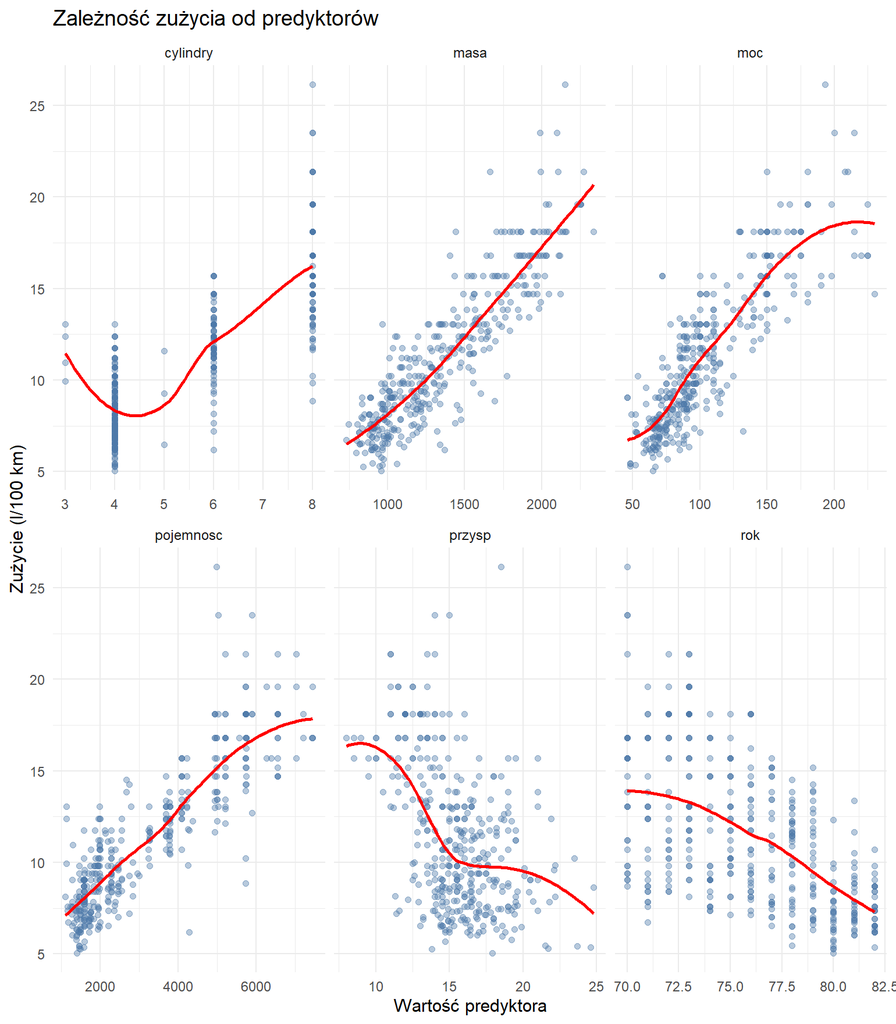

```r
df %>%
  dplyr::select(all_of(c(target_var, num_preds))) %>%
  pivot_longer(-zuzycie, names_to = "predictor", values_to = "value") %>%
  ggplot(aes(x = value, y = zuzycie)) +
  geom_point(alpha = 0.4, colour = "#4C78A8") +
  geom_smooth(method = "loess", se = FALSE, colour = "red", linewidth = 0.8) +
  facet_wrap(~ predictor, scales = "free_x", ncol = 3) +
  labs(title = "Zależność zużycia od predyktorów",
       x = "Wartość predyktora", y = "Zużycie (l/100 km)") +
  theme_minimal(base_size = 10)
```

## 5.7 Zużycie w przekroju pochodzenia

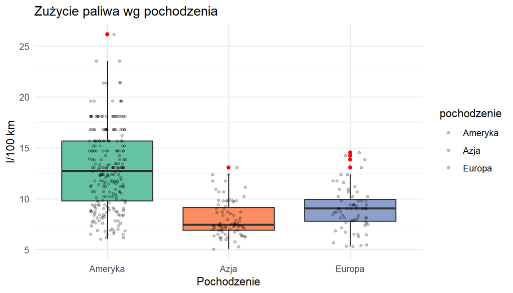

```r
ggplot(df, aes(x = pochodzenie, y = zuzycie, fill = pochodzenie)) +
  geom_boxplot(show.legend = FALSE, outlier.colour = "red") +
  geom_jitter(width = 0.15, alpha = 0.2, size = 1) +
  scale_fill_brewer(palette = "Set2") +
  labs(title = "Zużycie paliwa wg pochodzenia",
       x = "Pochodzenie", y = "l/100 km") +
  theme_minimal()
```

# 6 Podział na zbiór treningowy i testowy

> **📖 Przypomnienie teoretyczne - dlaczego dzielimy dane?**

> Model oceniany na danych, na których był trenowany, daje **optymistyczną** ocenę (bo „widział” te dane). Odłożony zbiór testowy symuluje nowe, niewidziane dane - daje uczciwą ocenę zdolności generalizacji.

> Proporcja 80/20 to popularna reguła kciuka. W tidymodels używamy `initial_split()`, który zapewnia **losowy, ale powtarzalny** podział (dzięki `set.seed()`).

```r
set.seed(42)

data_split <- initial_split(df %>% dplyr::select(-all_of(id_vars)),
                            prop = 0.80,
                            strata = zuzycie)  # stratyfikacja po Y

train_data <- training(data_split)
test_data  <- testing(data_split)

cat("Zbiór treningowy:", nrow(train_data), "obserwacji\n")
```

```
## Zbiór treningowy: 312 obserwacji
```

```r
cat("Zbiór testowy:   ", nrow(test_data), "obserwacji\n")
```

```
## Zbiór testowy:    80 obserwacji
```

## 6.1 Definicja foldów do walidacji krzyżowej

```r
cv_folds <- vfold_cv(train_data, v = 5, repeats = 3, strata = zuzycie)

cv_folds
```

| splits | id | id2 |
| --- | --- | --- |
|  | Repeat1 | Fold1 |
|  | Repeat1 | Fold2 |
|  | Repeat1 | Fold3 |
|  | Repeat1 | Fold4 |
|  | Repeat1 | Fold5 |
|  | Repeat2 | Fold1 |
|  | Repeat2 | Fold2 |
|  | Repeat2 | Fold3 |
|  | Repeat2 | Fold4 |
|  | Repeat2 | Fold5 |

[output cut: 5 more lines]

> **📖 Walidacja krzyżowa (v-fold CV)**

> Dane treningowe dzielimy na $v$ części (foldów). Model trenujemy na $v-1$ częściach, testujemy na 1. Powtarzamy $v$ razy. Uśrednione metryki dają stabilną ocenę generalizacji bez „zużywania” zbioru testowego. Stratyfikacja po zmiennej `zuzycie` zapewnia, że każdy fold ma podobny rozkład zmiennej zależnej.

> Stosujemy **powtórzoną** walidację krzyżową (`repeats = 3`), co oznacza trzykrotne powtórzenie losowego podziału na 5 foldów (łącznie 15 iteracji). Pojedynczy 5-fold CV zależy od jednego konkretnego podziału danych - powtórzenia uśredniają ten efekt i dają stabilniejsze estymaty metryk.

# 7 Preprocessing z recipes

> **📖 Przypomnienie teoretyczne — dlaczego `recipe`, a nie ręczne transformacje?**

> `recipe` definiuje **co** chcemy zrobić z danymi, ale **nie robi tego od razu**. Parametry (np. mediany, kwartyle, średnie) są obliczane dopiero na zbiorze treningowym w momencie `fit()`. Dzięki temu zbiór testowy **nigdy nie wpływa** na transformację - to eliminuje wyciek danych (*data leakage*).

> **⚠️ Pułapka - data leakage:** Jeśli policzysz średnią do standaryzacji na **całych** danych (przed podziałem train/test), to informacja ze zbioru testowego „przecieka” do treningu. Wynik na teście będzie optymistyczny, ale model gorzej zadziała w produkcji. `recipe` chroni przed tym automatycznie.

## 7.1 Definicja przepisu (recipe)

**📖 Po co standaryzacja w regresji?**

Standaryzacja (z-score) w regresji liniowej i LASSO pełni dwie funkcje:

1. **Porównywalność współczynników** - bez standaryzacji współczynnik przy `moc` (zakres 46–230 KM) i przy przysp (zakres ~8–25 s) mają nieporównywalne skale. Po standaryzacji każdy współczynnik mówi: „o ile zmieni się Y, gdy X wzrośnie o jedno odchylenie standardowe” - można je zestawić obok siebie i ocenić, która zmienna ma najsilniejszy wpływ.
2. **Poprawne działanie regularyzacji** - LASSO nakłada karę proporcjonalną do sumy wartości bezwzględnych współczynników (α · Σ|βⱼ|). Jeśli zmienne mają różne skale, kara uderza nierówno
   - zmienna o dużym zakresie ma „naturalnie” mały współczynnik i unika kary, a zmienna o małym zakresie jest niesprawiedliwie karana. Standaryzacja wyrównuje szanse.

Dla samego dopasowania OLS (R², RMSE) standaryzacja **nie zmienia wyniku** - predykcje będą identyczne. Zmienia się jedynie interpretacja współczynników. Natomiast dla LASSO jest **obowiązkowa** - bez niej selekcja zmiennych będzie zaburzona.

```r
base_recipe <- recipe(zuzycie ~ ., data = train_data) %>%

  # --- Rola zmiennych ---
  # (wszystkie poza zuzycie są predyktorami — recipe robi to domyślnie)

  # --- Wartości odstające: winsoryzacja IQR ---
  # Granice są estymowane w prep() na danych uczących i zapamiętywane.
  # Następnie bake() stosuje te same granice do danych walidacyjnych/testowych.
  step_winsorize_iqr(pojemnosc, moc, masa, przysp, multiplier = 1.5) %>%

  # --- Kodowanie zmiennej jakościowej (one-hot, drop first) ---
  step_dummy(all_nominal_predictors(), one_hot = FALSE) %>%

  # --- Usunięcie predyktorów o zerowej wariancji ---
  step_zv(all_predictors()) %>%

  # --- Standaryzacja z-score ---
  step_normalize(all_numeric_predictors())

base_recipe
```

Winsoryzację stosujemy wyłącznie do zmiennych ciągłych (`pojemnosc`, `moc`, `masa`, `przysp`), a nie do wszystkich predyktorów numerycznych. Zmienna `rok` jest serią czasową, w której skrajne wartości oznaczają po prostu najstarsze i najnowsze roczniki - ich przycinanie zafałszowałoby trend. Z kolei `cylindry` przyjmuje tylko kilka dyskretnych wartości (3, 4, 5, 6, 8), więc pojęcie odstającego punktu w sensie IQR nie ma tu zastosowania.

### 7.1.1 Podgląd efektów recipe

Funkcja `prep()` „uczy” przepis na zbiorze treningowym - oblicza wszystkie potrzebne parametry: granice IQR do winsoryzacji, poziomy zmiennych jakościowych do kodowania oraz średnie i odchylenia do standaryzacji. Funkcja `bake()` **stosuje** wyuczony przepis do wskazanych danych - tu podajemy `train_data`, żeby podejrzeć efekt, ale moglibyśmy podać `test_data` i transformacja użyłaby parametrów obliczonych wyłącznie na treningu.

W normalnym workflow **nie wywołujemy** `prep()` i `bake()` ręcznie - robi to za nas `fit()` wewnątrz workflow. Robimy to tutaj w celach dydaktycznych: `glimpse(baked)` pozwala sprawdzić, czy zmienne zostały poprawnie zakodowane (dummy), przeskalowane (z-score) i czy nie pojawiły się niespodziewane kolumny lub wartości NA.

```r
prepped <- prep(base_recipe, training = train_data)
baked   <- bake(prepped, new_data = train_data)

glimpse(baked)
```

```
## Rows: 312
## Columns: 9
## $ cylindry           <dbl> -0.865, -0.865, -0.865, -0.865, -0.865, -0.865, -0.…
## $ pojemnosc          <dbl> -1.0212, -1.1829, -1.1734, -1.2114, -1.1068, -0.926…
## $ moc                <dbl> -0.7329, -1.0241, -0.9182, -1.4475, -0.9711, -0.547…
## $ masa               <dbl> -1.0532, -1.3948, -1.5820, -1.2848, -1.1877, -0.873…
## $ przysp             <dbl> -0.3842, 1.2957, 0.9224, 1.4823, 1.2957, 0.3624, 0.…
## $ rok                <dbl> -1.33098, -1.33098, -1.33098, -0.78744, -0.51567, -…
## $ zuzycie            <dbl> 7.841, 7.588, 6.721, 8.111, 7.588, 8.111, 7.588, 7.…
## $ pochodzenie_Azja   <dbl> -0.4771, 2.0893, 2.0893, -0.4771, 2.0893, -0.4771, …
## $ pochodzenie_Europa <dbl> 2.2586, -0.4413, -0.4413, 2.2586, -0.4413, 2.2586, …
```

```r
tidy(prepped, number = 1) %>%
  kable(digits = 2,
        caption = "Granice winsoryzacji obliczone na zbiorze treningowym")
```

Granice winsoryzacji obliczone na zbiorze treningowym

| terms | lower | upper | id |
| --- | --- | --- | --- |
| pojemnosc | -2456.97 | 8608.6 | winsorize_iqr_ztPtl |
| moc | 0.00 | 200.0 | winsorize_iqr_ztPtl |
| masa | 79.95 | 2558.0 | winsorize_iqr_ztPtl |
| przysp | 8.70 | 22.3 | winsorize_iqr_ztPtl |

> W podejściu tidymodels **nie musimy** wywoływać `prep()` i `bake()` ręcznie - workflow robi to automatycznie. Robimy to tutaj wyłącznie w celach dydaktycznych, żeby sprawdzić efekt transformacji.

### 7.1.2 Wersja recipe bez standaryzacji (dla drzew)

Modele drzewiaste nie wymagają standaryzacji - skale zmiennych nie wpływają na podziały. Definiujemy osobny recipe:

```r
tree_recipe <- recipe(zuzycie ~ ., data = train_data) %>%
  step_winsorize_iqr(pojemnosc, moc, masa, przysp, multiplier = 1.5) %>%
  step_dummy(all_nominal_predictors(), one_hot = FALSE) %>%
  step_zv(all_predictors())
```

# 8 Zbiór metryk do ewaluacji

Definiujemy raz - używamy wszędzie:

```r
reg_metrics <- metric_set(rmse, rsq, mae, mape)
```

# 9 Model 1: Regresja liniowa (OLS)

> **📖 Przypomnienie teoretyczne — regresja liniowa**

> Regresja liniowa szuka współczynników $\beta_0, \beta_1, \ldots, \beta_p$ minimalizujących sumę kwadratów reszt:

> $$\hat{y} = \beta_0 + \beta_1 x_1 +
> \ldots + \beta_p x_p$$

> Założenia: liniowość zależności, normalność reszt, stałość wariancji (homoscedastyczność), brak silnej współliniowości. Naruszenie założeń nie unieważnia modelu, ale wpływa na wiarygodność przedziałów ufności i p-wartości.

## 9.1 Specyfikacja modelu i workflow

W tym kroku definiujemy typ modelu regresji liniowej oraz łączymy go z przygotowanym wcześniej przepisem przetwarzania danych (`base_recipe`) w jeden obiekt `workflow`, który będzie można trenować i oceniać w uporządkowany sposób.

```r
lm_spec <- linear_reg() %>%
  set_engine("lm") %>%
  set_mode("regression")

lm_wf <- workflow() %>%
  add_recipe(base_recipe) %>%
  add_model(lm_spec)

lm_wf
```

```
## ══ Workflow ════════════════════════════════════════════════════════════════════
## Preprocessor: Recipe
## Model: linear_reg()
##
## ── Preprocessor ────────────────────────────────────────────────────────────────
## 4 Recipe Steps
##
## • step_winsorize_iqr()
## • step_dummy()
## • step_zv()
## • step_normalize()
##
## ── Model ───────────────────────────────────────────────────────────────────────
## Linear Regression Model Specification (regression)
##
## Computational engine: lm
```

## 9.2 Walidacja krzyżowa

W tym kroku oceniamy model regresji liniowej za pomocą walidacji krzyżowej: model jest wielokrotnie trenowany na części danych treningowych i sprawdzany na pozostałej części, dzięki czemu otrzymujemy bardziej stabilną ocenę jakości niż przy pojedynczym podziale danych.

```r
lm_cv <- fit_resamples(
  lm_wf,
  resamples = cv_folds,
  metrics   = reg_metrics,
  control   = control_resamples(save_pred = TRUE)
)

collect_metrics(lm_cv)
```

| .metric | .estimator | mean | n | std_err | .config |
| --- | --- | --- | --- | --- | --- |
| mae | standard | 0.9697 | 15 | 0.028609 | pre0_mod0_post0 |
| mape | standard | 8.9736 | 15 | 0.251259 | pre0_mod0_post0 |
| rmse | standard | 1.2703 | 15 | 0.043650 | pre0_mod0_post0 |
| rsq | standard | 0.8967 | 15 | 0.006163 | pre0_mod0_post0 |

## 9.3 Dopasowanie na pełnym zbiorze treningowym

Po ocenie modelu za pomocą walidacji krzyżowej dopasowujemy regresję liniową na całym zbiorze treningowym, aby uzyskać finalne współczynniki modelu. Ponieważ predyktory numeryczne zostały wcześniej wystandaryzowane, wartości współczynników można łatwiej porównywać między sobą pod względem siły związku ze zmienną objaśnianą.

```r
lm_fit <- fit(lm_wf, data = train_data)

# Współczynniki modelu
lm_fit %>%
  extract_fit_parsnip() %>%
  tidy() %>%
  arrange(desc(abs(estimate))) %>%
  kable(caption = "Współczynniki regresji liniowej (dane standaryzowane)",
        digits = 4)
```

Współczynniki regresji liniowej (dane standaryzowane)

| term | estimate | std.error | statistic | p.value |
| --- | --- | --- | --- | --- |
| (Intercept) | 11.2626 | 0.0708 | 159.057 | 0.0000 |
| masa | 2.1939 | 0.2556 | 8.585 | 0.0000 |
| moc | 1.5298 | 0.2359 | 6.485 | 0.0000 |
| rok | -1.1681 | 0.0818 | -14.279 | 0.0000 |
| pojemnosc | -1.0473 | 0.3436 | -3.048 | 0.0025 |
| cylindry | 0.6198 | 0.2402 | 2.580 | 0.0103 |
| przysp | 0.3272 | 0.1167 | 2.804 | 0.0054 |
| pochodzenie_Europa | -0.1839 | 0.0894 | -2.057 | 0.0405 |
| pochodzenie_Azja | -0.1230 | 0.0911 | -1.351 | 0.1777 |

W tabeli warto zwrócić uwagę nie tylko na istotność statystyczną, ale także na znaki współczynników. Część z nich jest intuicyjna: większa `masa` i większa `moc` wiążą się z większym zużyciem paliwa, a nowszy `rok` produkcji z mniejszym zużyciem. Pojawiają się jednak również wyniki pozornie kontrintuicyjne: `pojemnosc` ma współczynnik ujemny, a `przysp` dodatni. Nie należy interpretować ich jako prostych zależności „sam na sam”, ponieważ model uwzględnia wszystkie zmienne jednocześnie. Przy silnej współliniowości między `pojemnosc`, `cylindry`, `masa` i `moc` model może mieć trudność z jednoznacznym przypisaniem wpływu poszczególnym predyktorom, co prowadzi do niestabilnych lub odwróconych znaków współczynników.

```r
lm_train_pred <- lm_fit %>%
  augment(new_data = train_data)
```

## 9.4 Diagnostyka reszt

Diagnostyka reszt pozwala sprawdzić, czy model liniowy dobrze opisuje strukturę danych. Na wykresie „obserwowane vs przewidywane” punkty powinny układać się możliwie blisko czerwonej linii przerywanej — im większe odchylenia od tej linii, tym większe błędy predykcji. Drugi wykres pokazuje reszty względem wartości przewidywanych. W idealnej sytuacji reszty powinny być rozproszone losowo wokół zera, bez wyraźnego wzorca. Jeżeli pojawia się łuk, wachlarz albo grupowanie punktów, może to sugerować nieliniowość, heteroskedastyczność albo obecność obserwacji nietypowych.

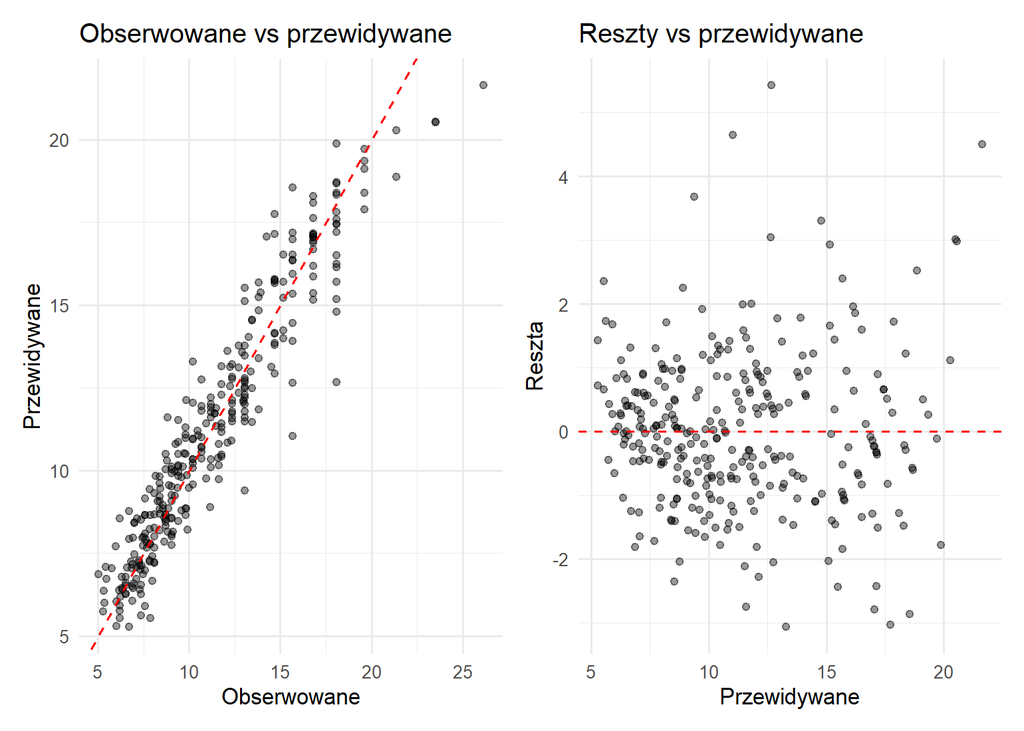

```r
p_obs_pred <- ggplot(lm_train_pred, aes(x = zuzycie, y = .pred)) +
  geom_point(alpha = 0.4) +
  geom_abline(colour = "red", linetype = "dashed") +
  labs(title = "Obserwowane vs przewidywane",
       x = "Obserwowane", y = "Przewidywane") +
  theme_minimal()

p_resid <- ggplot(lm_train_pred, aes(x = .pred, y = zuzycie - .pred)) +
  geom_point(alpha = 0.4) +
  geom_hline(yintercept = 0, colour = "red", linetype = "dashed") +
  labs(title = "Reszty vs przewidywane",
       x = "Przewidywane", y = "Reszta") +
  theme_minimal()

p_obs_pred + p_resid
```

# 10 Model 2: Regresja LASSO

> **📖 Przypomnienie teoretyczne - regularyzacja LASSO (L1)**

> LASSO minimalizuje:

> $$\sum(y_i - \hat{y}_i)^2 + \alpha
> \sum_{j=1}^{p} |\beta_j|$$

> Kara $\alpha$ „ściska” współczynniki ku zeru. Wystarczająco duża $\alpha$ powoduje, że część współczynników wyniesie **dokładnie zero** - LASSO działa więc jak automatyczna selekcja zmiennych.

> Hiperparametr `penalty` ($\alpha$) dobieramy przez tuning. `mixture = 1` oznacza czyste LASSO (mixture = 0 to Ridge, 0 < m < 1 to Elastic Net).

## 10.1 Specyfikacja ze strojeniem

W tym kroku definiujemy model LASSO, czyli regresję liniową z regularyzacją L1, która może zmniejszać część współczynników dokładnie do zera i tym samym wykonywać selekcję zmiennych. Hiperparametr `penalty` nie jest ustawiany ręcznie, lecz oznaczony jako `tune()`, ponieważ jego optymalną wartość dobierzemy później na podstawie walidacji krzyżowej.

```r
lasso_spec <- linear_reg(
  penalty = tune(),    # strojony hiperparametr
  mixture = 1          # LASSO (L1)
) %>%
  set_engine("glmnet") %>%
  set_mode("regression")

lasso_wf <- workflow() %>%
  add_recipe(base_recipe) %>%
  add_model(lasso_spec)
```

## 10.2 Siatka wartości penalty

Tworzymy siatkę wartości parametru `penalty`, czyli siły regularyzacji w modelu LASSO. Podczas walidacji krzyżowej model zostanie przetestowany dla wielu różnych wartości tej kary, aby wybrać taką, która daje najlepszą jakość predykcji.

```r
lasso_grid <- grid_regular(
  penalty(range = c(-4, 0)),  # 10^(-4) do 10^0
  levels = 30
)
```

## 10.3 Strojenie przez v-fold CV

W tym kroku uruchamiamy strojenie modelu LASSO: dla każdej wartości parametru `penalty` z wcześniej utworzonej siatki model jest oceniany w walidacji krzyżowej. Dzięki temu możemy sprawdzić, jaka siła regularyzacji daje najlepszy kompromis między dokładnością predykcji a uproszczeniem modelu.

```r
lasso_tune <- tune_grid(
  lasso_wf,
  resamples = cv_folds,
  grid      = lasso_grid,
  metrics   = reg_metrics,
  control   = control_grid(save_pred = TRUE)
)
```

### 10.3.1 Wizualizacja ścieżki strojenia

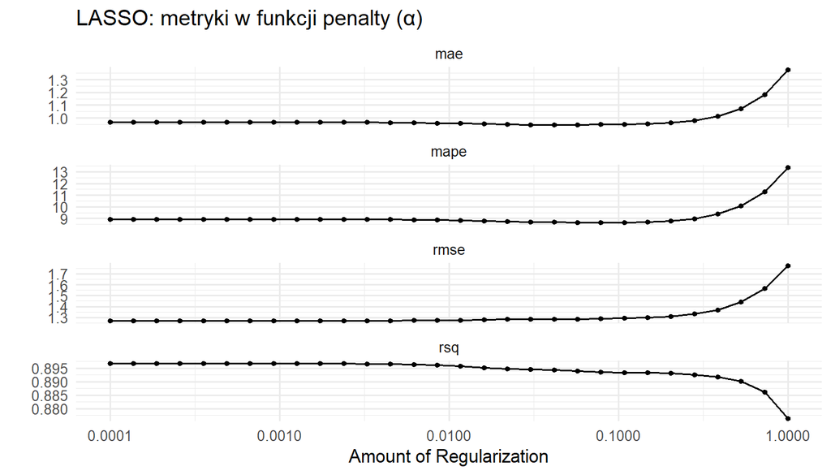

```r
autoplot(lasso_tune) +
  labs(title = "LASSO: metryki w funkcji penalty (α)") +
  theme_minimal()
```

Na wykresie widać, że dla małych i umiarkowanych wartości `penalty` jakość modelu jest bardzo podobna - wartości błędów (`MAE`, `MAPE`, `RMSE`) pozostają prawie płaskie, a `R²` tylko nieznacznie się zmienia. Dopiero przy zbyt dużej regularyzacji błędy zaczynają szybko rosnąć, a `R²` spada, co oznacza, że model staje się zbyt mocno uproszczony i traci zdolność dobrego przewidywania zużycia paliwa.

### 10.3.2 Wybór najlepszego penalty

```r
lasso_best <- select_by_one_std_err(
  lasso_tune,
  metric = "rmse",
  desc(penalty)
)
lasso_best
```

| penalty | .config |
| --- | --- |
| 0.2043 | pre0_mod25_post0 |

```r
lasso_final_wf <- finalize_workflow(lasso_wf, lasso_best)
lasso_fit <- fit(lasso_final_wf, data = train_data)
```

Dla LASSO stosujemy **regułę jednego błędu standardowego** (*1-SE rule*), a nie `select_best()`. Wybieramy najwyższą wartość `penalty`, której RMSE mieści się w granicach 1 SE od bezwzględnie najlepszego wyniku. Silniejsza kara oznacza więcej wyzerowanych współczynników, a więc prostszy model - i to jest tu celem: chcemy zobaczyć, które zmienne LASSO uzna za zbędne w porównaniu z pełnym modelem OLS.

Dla CART i XGBoost stosujemy `select_best()`, bo tam prostota modelu jest kontrolowana bezpośrednio przez hiperparametry strukturalne (głębokość drzewa, `min_n`), a nie przez mechanizm zerowania zmiennych.

### 10.3.3 Które zmienne zostały wyzerowane?

```r
lasso_coefs <- lasso_fit %>%
  extract_fit_parsnip() %>%
  tidy() %>%
  filter(term != "(Intercept)") %>%
  arrange(desc(abs(estimate)))

kable(lasso_coefs,
      caption = "Współczynniki LASSO (niezerowe = wybrane przez model)",
      digits = 4)
```

Współczynniki LASSO (niezerowe = wybrane przez model)

| term | estimate | penalty |
| --- | --- | --- |
| masa | 2.1152 | 0.2043 |
| rok | -0.9880 | 0.2043 |
| moc | 0.8618 | 0.2043 |
| cylindry | 0.0775 | 0.2043 |
| pojemnosc | 0.0000 | 0.2043 |
| przysp | 0.0000 | 0.2043 |
| pochodzenie_Azja | 0.0000 | 0.2043 |
| pochodzenie_Europa | 0.0000 | 0.2043 |

```r
cat("\nLiczba wyzerowanych zmiennych:",
    sum(lasso_coefs$estimate == 0), "/", nrow(lasso_coefs), "\n")
```

```
##
## Liczba wyzerowanych zmiennych: 4 / 8
```

### 10.3.4 Metryki CV dla LASSO

```r
lasso_cv_metrics <- lasso_tune %>%
  collect_metrics() %>%
  filter(.config == lasso_best$.config)

lasso_cv_metrics
```

| penalty | .metric | .estimator | mean | n | std_err | .config |
| --- | --- | --- | --- | --- | --- | --- |
| 0.2043 | mae | standard | 0.9617 | 15 | 0.029955 | pre0_mod25_post0 |
| 0.2043 | mape | standard | 8.7785 | 15 | 0.273822 | pre0_mod25_post0 |
| 0.2043 | rmse | standard | 1.3105 | 15 | 0.049946 | pre0_mod25_post0 |
| 0.2043 | rsq | standard | 0.8930 | 15 | 0.006697 | pre0_mod25_post0 |

# 11 Model 3: Drzewo regresyjne (CART)

> **📖 Przypomnienie teoretyczne - drzewa decyzyjne (CART)**

> Drzewo rekurencyjnie dzieli przestrzeń predyktorów na prostokątne regiony. W każdym węźle szuka zmiennej i progu, które minimalizują sumę kwadratów reszt w powstałych podgrupach.

> Kluczowe hiperparametry:

> | Parametr | Znaczenie |
> | --- | --- |
> | `tree_depth` | maks. głębokość drzewa |
> | `min_n` | min. obserwacji w liściu |
> | `cost_complexity` | parametr przycinania (cp) - im większy, tym prostsze drzewo |

> **Zalety:** interpretowalność, brak założeń o rozkładach, odporność na kolinearność. **Wady:** tendencja do przeuczenia, niestabilność (mała zmiana danych → inne drzewo).

## 11.1 Specyfikacja ze strojeniem

W tym kroku definiujemy model drzewa regresyjnego CART, w którym strojone będą trzy hiperparametry: maksymalna głębokość drzewa (`tree_depth`), minimalna liczba obserwacji w liściu (`min_n`) oraz siła przycinania drzewa (`cost_complexity`). W workflow używamy osobnego przepisu `tree_recipe`, ponieważ modele drzewiaste nie wymagają standaryzacji zmiennych - podziały są wykonywane na podstawie progów wartości, a nie na podstawie odległości czy wielkości współczynników.

```r
cart_spec <- decision_tree(
  tree_depth      = tune(),
  min_n           = tune(),
  cost_complexity = tune()
) %>%
  set_engine("rpart") %>%
  set_mode("regression")

cart_wf <- workflow() %>%
  add_recipe(tree_recipe) %>%    # bez standaryzacji

  add_model(cart_spec)
```

## 11.2 Siatka hiperparametrów

```r
cart_grid <- grid_regular(
  tree_depth(range = c(2, 8)),
  min_n(range = c(2, 20)),
  cost_complexity(range = c(-4, -1)),
  levels = 4
)

cat("Kombinacji do przeszukania:", nrow(cart_grid), "\n")
```

```
## Kombinacji do przeszukania: 64
```

## 11.3 Strojenie

```r
cart_tune <- tune_grid(
  cart_wf,
  resamples = cv_folds,
  grid      = cart_grid,
  metrics   = reg_metrics,
  control   = control_grid(save_pred = TRUE)
)
```

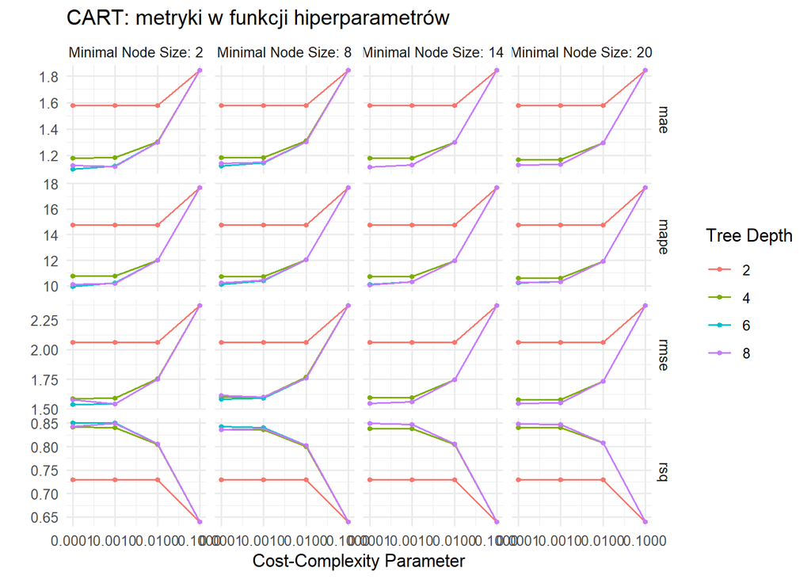

```r
autoplot(cart_tune) +
  labs(title = "CART: metryki w funkcji hiperparametrów") +
  theme_minimal()
```

### 11.3.1 Najlepszy model CART

```r
cart_best <- select_best(cart_tune, metric = "rmse")
cart_best
```

| cost_complexity | tree_depth | min_n | .config |
| --- | --- | --- | --- |
| 0.0001 | 6 | 2 | pre0_mod09_post0 |

```r
cart_final_wf <- finalize_workflow(cart_wf, cart_best)
cart_fit <- fit(cart_final_wf, data = train_data)
```

### 11.3.2 Wizualizacja drzewa

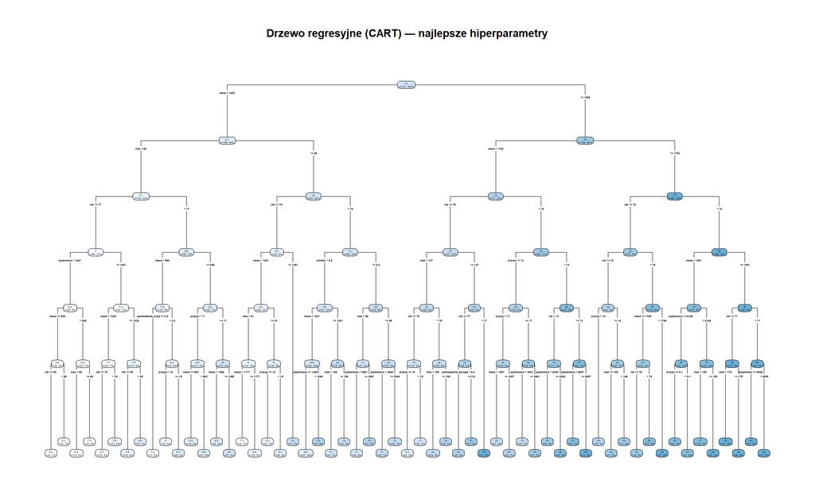

```r
cart_fit %>%
  extract_fit_engine() %>%
  rpart.plot(roundint = FALSE,
             type = 4,
             extra = 101,
             fallen.leaves = TRUE,
             main = "Drzewo regresyjne (CART) — najlepsze hiperparametry")
```

# 12 Model 4: XGBoost

> **📖 Przypomnienie teoretyczne — Gradient Boosting (XGBoost)**

> XGBoost buduje **sekwencję** drzew, z których każde kolejne koryguje błędy poprzednich. Proces:
> 1. Dopasuj proste drzewo do danych.
> 2. Oblicz reszty (błędy).
> 3. Dopasuj następne drzewo **do reszt**.
> 4. Dodaj je do ensemblu z wagą `learning_rate`.
> 5. Powtarzaj.

> Kluczowe hiperparametry:

> | Parametr | tidymodels | Znaczenie |
> | --- | --- | --- |
> | n_estimators | `trees` | liczba drzew w ensemblu |
> | max_depth | `tree_depth` | głębokość pojedynczego drzewa |
> | learning_rate | `learn_rate` | tempo uczenia |
> | subsample | `sample_size` | % obserwacji na drzewo |
> | colsample_bytree | `mtry` | % zmiennych na drzewo |
> | min_child_weight | `min_n` | min. obserwacji w liściu |
> | gamma | `loss_reduction` | min. redukcja straty do podziału węzła |

## 12.1 Specyfikacja ze strojeniem

```r
xgb_spec <- boost_tree(
  trees      = tune(),
  tree_depth = tune(),
  learn_rate = tune(),
  min_n      = tune(),
  sample_size = 0.8,
  mtry        = tune()
) %>%
  set_engine("xgboost") %>%
  set_mode("regression")

xgb_wf <- workflow() %>%
  add_recipe(tree_recipe) %>%    # bez standaryzacji
  add_model(xgb_spec)
```

## 12.2 Siatka hiperparametrów

```r
xgb_grid <- grid_space_filling(
  trees(range = c(80, 300)),
  tree_depth(range = c(2, 6)),
  learn_rate(range = c(-2, -0.5)),   # 0.01 – 0.3
  min_n(range = c(2, 10)),
  finalize(mtry(), bake(prep(tree_recipe, train_data), train_data) %>%
           dplyr::select(-zuzycie)),
  size = 40
)

cat("Kombinacji do przeszukania:", nrow(xgb_grid), "\n")
```

```
## Kombinacji do przeszukania: 40
```

> 📖 **Siatka space-filling** - w przeciwieństwie do regularnej siatki (`grid_regular()`), metoda ta dobiera punkty tak, aby możliwie dobrze pokryć przestrzeń hiperparametrów przy ograniczonej liczbie prób. Dzięki temu np. 40 punktów może dać bardziej użyteczne pokrycie przestrzeni niż 40 kombinacji z prostej regularnej siatki, szczególnie gdy stroimy kilka hiperparametrów jednocześnie.

## 12.3 Strojenie

```r
xgb_tune <- tune_grid(
  xgb_wf,
  resamples = cv_folds,
  grid      = xgb_grid,
  metrics   = reg_metrics,
  control   = control_grid(save_pred = TRUE)
)
```

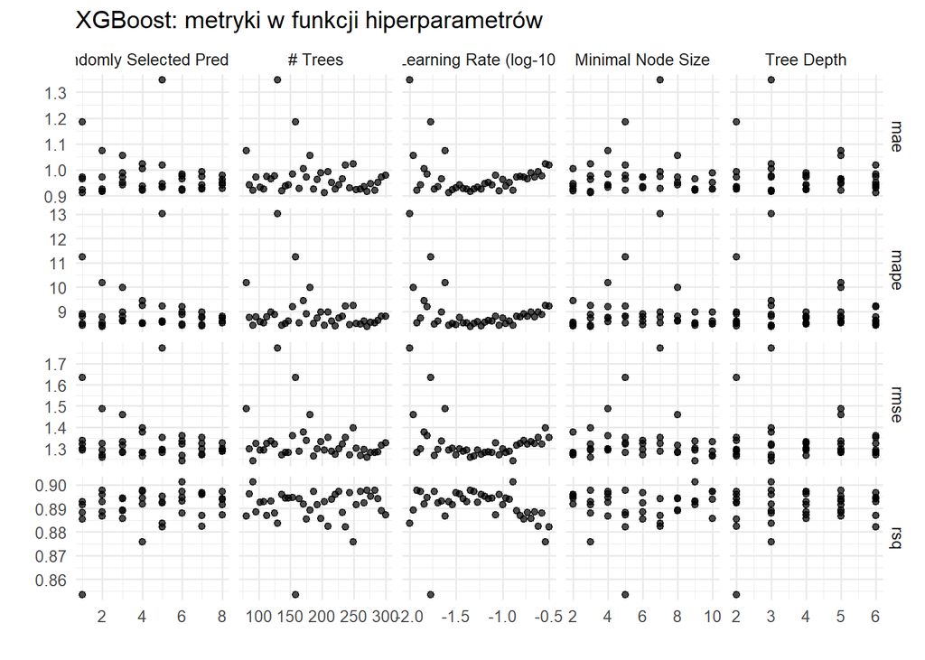

```r
autoplot(xgb_tune) +
  labs(title = "XGBoost: metryki w funkcji hiperparametrów") +
  theme_minimal()
```

### 12.3.1 Najlepszy model XGBoost

```r
xgb_best <- select_best(xgb_tune, metric = "rmse")
xgb_best
```

| mtry | trees | min_n | tree_depth | learn_rate | .config |
| --- | --- | --- | --- | --- | --- |
| 6 | 91 | 9 | 3 | 0.1304 | pre0_mod26_post0 |

```r
xgb_final_wf <- finalize_workflow(xgb_wf, xgb_best)
xgb_fit <- fit(xgb_final_wf, data = train_data)
```

# 13 Porównanie modeli - metryki z walidacji krzyżowej

## 13.1 Zebranie metryk

```r
# Dla LASSO i drzew bierzemy najlepszą konfigurację
lasso_best_cv <- lasso_tune %>%
  collect_metrics() %>%
  filter(.config == lasso_best$.config) %>%
  mutate(model = "LASSO")

cart_best_cv <- cart_tune %>%
  collect_metrics() %>%
  filter(.config == cart_best$.config) %>%
  mutate(model = "CART")

xgb_best_cv <- xgb_tune %>%
  collect_metrics() %>%
  filter(.config == xgb_best$.config) %>%
  mutate(model = "XGBoost")

lm_cv_metrics <- collect_metrics(lm_cv) %>%
  mutate(model = "OLS")

all_cv <- bind_rows(lm_cv_metrics, lasso_best_cv, cart_best_cv, xgb_best_cv) %>%
  dplyr::select(model, .metric, mean, std_err) %>%
  arrange(.metric, mean)
```

```r
all_cv %>%
  pivot_wider(names_from = .metric,
              values_from = c(mean, std_err)) %>%
  kable(caption = "Porównanie modeli — metryki CV (średnia ± SE)",
        digits = 4)
```

Porównanie modeli — metryki CV (średnia ± SE)

| model | mean_mae | mean_mape | mean_rmse | mean_rsq | std_err_mae | std_err_mape | std_err_rmse | std_err_rsq |
| --- | --- | --- | --- | --- | --- | --- | --- | --- |
| XGBoost | 0.9222 | 8.430 | 1.242 | 0.9011 | 0.0222 | 0.2074 | 0.0368 | 0.0060 |
| LASSO | 0.9617 | 8.778 | 1.310 | 0.8930 | 0.0300 | 0.2738 | 0.0499 | 0.0067 |
| OLS | 0.9697 | 8.974 | 1.270 | 0.8967 | 0.0286 | 0.2513 | 0.0437 | 0.0062 |
| CART | 1.0956 | 9.930 | 1.541 | 0.8500 | 0.0368 | 0.3182 | 0.0651 | 0.0103 |

## 13.2 Wizualizacja porównania

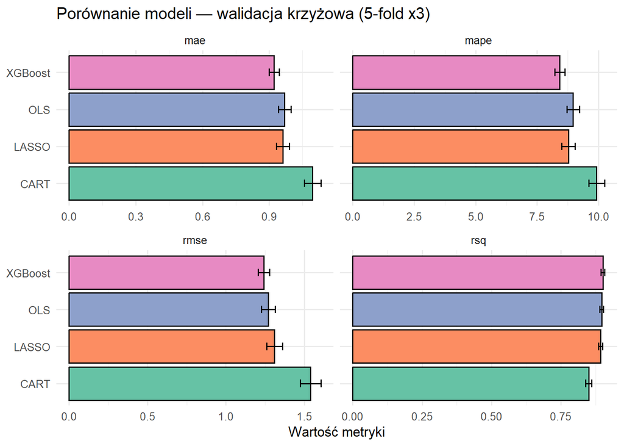

```r
all_cv %>%
  ggplot(aes(x = mean, y = model, fill = model)) +
  geom_col(show.legend = FALSE, colour = "black") +
  geom_errorbar(
    aes(xmin = mean - std_err, xmax = mean + std_err),
    width = 0.2
  ) +
  facet_wrap(~ .metric, scales = "free_x", ncol = 2) +
  scale_fill_brewer(palette = "Set2") +
  labs(title = "Porównanie modeli — walidacja krzyżowa (5-fold x3)",
       x = "Wartość metryki", y = NULL) +
  theme_minimal()
```

# 14 Ewaluacja na zbiorze testowym

> **⚠️ Pułapka - zbiór testowy otwieramy TYLKO RAZ.** Wielokrotna ewaluacja na teście prowadzi do „optymizmu selekcyjnego” - efekt jest taki sam jak brak podziału. Wybraliśmy model na podstawie CV; teraz sprawdzamy go na teście po raz pierwszy i ostatni.

Na potrzeby tego materiału ewaluację na zbiorze testowym przeprowadzamy na modelu XGBoost, ponieważ dalsza część analizy (wartości SHAP) korzysta bezpośrednio z natywnego API tego silnika. W pełni zautomatyzowanym pipeline produkcyjnym wybór modelu powinien być programowy - np. na podstawie najniższego RMSE z tabeli `all_cv`.

```r
# Wybieramy najlepszy model (na podstawie RMSE z CV) — tu zakładamy XGBoost
final_fit <- last_fit(xgb_final_wf, split = data_split, metrics = reg_metrics)

collect_metrics(final_fit) %>%
  kable(caption = "Metryki na zbiorze testowym (najlepszy model)",
        digits = 4)
```

Metryki na zbiorze testowym (najlepszy model)

| .metric | .estimator | .estimate | .config |
| --- | --- | --- | --- |
| rmse | standard | 1.4249 | pre0_mod0_post0 |
| rsq | standard | 0.8661 | pre0_mod0_post0 |
| mae | standard | 1.0690 | pre0_mod0_post0 |
| mape | standard | 9.9244 | pre0_mod0_post0 |

## 14.1 Wykres obserwowane vs przewidywane (test)

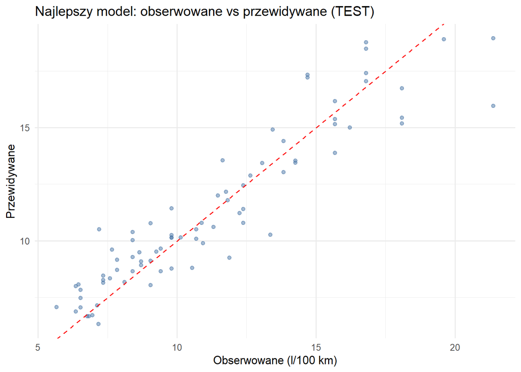

```r
test_pred <- collect_predictions(final_fit)

ggplot(test_pred, aes(x = zuzycie, y = .pred)) +
  geom_point(alpha = 0.5, colour = "#4C78A8") +
  geom_abline(colour = "red", linetype = "dashed") +
  labs(title = "Najlepszy model: obserwowane vs przewidywane (TEST)",
       x = "Obserwowane (l/100 km)", y = "Przewidywane") +
  theme_minimal()
```

## 14.2 Rozkład reszt na zbiorze testowym

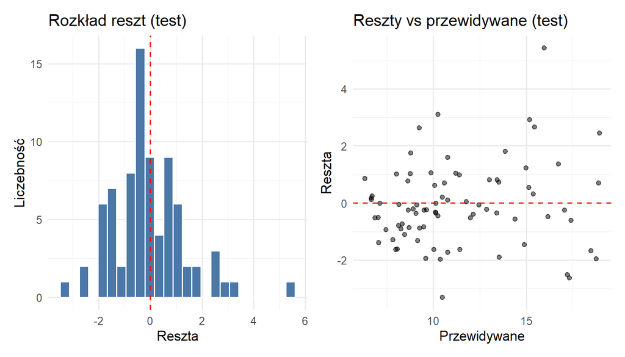

```r
test_pred <- test_pred %>%
  mutate(residual = zuzycie - .pred)

p_hist_r <- ggplot(test_pred, aes(x = residual)) +
  geom_histogram(bins = 25, fill = "#4C78A8", colour = "white") +
  geom_vline(xintercept = 0, colour = "red", linetype = "dashed") +
  labs(title = "Rozkład reszt (test)", x = "Reszta", y = "Liczebność") +
  theme_minimal()

p_resid_pred <- ggplot(test_pred, aes(x = .pred, y = residual)) +
  geom_point(alpha = 0.5) +
  geom_hline(yintercept = 0, colour = "red", linetype = "dashed") +
  labs(title = "Reszty vs przewidywane (test)",
       x = "Przewidywane", y = "Reszta") +
  theme_minimal()

p_hist_r + p_resid_pred
```

# 15 Interpretowalność modelu

## 15.1 Analiza SHAP (*)

Ta sekcja jest pokazowa. Jeśli wystąpi problem z pakietem `shapviz`, nie blokuje to wykonania głównych zadań.

> **📖 Przypomnienie teoretyczne — SHAP**

> SHAP (*SHapley Additive exPlanations*) pokazuje, jak poszczególne zmienne wpływają na predykcję modelu dla konkretnej obserwacji. Punktem odniesienia jest wartość bazowa modelu, czyli przeciętna predykcja modelu dla danych referencyjnych.

> Dla pojedynczej obserwacji predykcję można zapisać intuicyjnie jako:

> $$\text{predykcja} = \text{wartość bazowa}
> + \sum \text{wkładów SHAP}$$
> - **SHAP > 0** — dana cecha podwyższa predykcję względem wartości bazowej.
> - **SHAP < 0** — dana cecha obniża predykcję względem wartości bazowej.
> - **|SHAP|** — informuje o sile wpływu danej cechy.

> Wartości SHAP nie są współczynnikami regresji. Nie mówią, że zmienna ma jeden stały wpływ w całym modelu. Pokazują wkład zmiennej w konkretnej predykcji, z uwzględnieniem pozostałych cech obserwacji.

```r
# Wyciągamy wytrenowany silnik XGBoost z workflow
xgb_engine <- extract_fit_engine(xgb_fit)

# Wyciągamy przygotowany recipe z finalnego workflow.
# To ważne: SHAP liczymy na tych samych zmiennych, które widział model,
# czyli po winsoryzacji, kodowaniu zmiennych jakościowych i usunięciu zmiennych zerowej wariancji.
xgb_recipe_prepped <- extract_recipe(xgb_fit, estimated = TRUE)

# Przygotowujemy dane treningowe dokładnie tak, jak były przygotowane dla modelu XGBoost
x_train_baked <- bake(xgb_recipe_prepped, new_data = train_data)

x_train_xgb <- x_train_baked %>%
  dplyr::select(-zuzycie)

x_train_matrix <- as.matrix(x_train_xgb)

# Natywne wartości SHAP z XGBoost.
# predcontrib = TRUE zwraca wkłady zmiennych oraz ostatnią kolumnę BIAS,
# czyli wartość bazową modelu.
shap_contrib <- predict(
  xgb_engine,
  newdata = x_train_matrix,
  predcontrib = TRUE
)

# Ostatnia kolumna to BIAS / wartość bazowa.
# W regresji XGBoost BIAS jest taki sam dla wszystkich obserwacji;
# używamy średniej, aby nie sugerować, że wybór wiersza ma znaczenie.
bias_col <- ncol(shap_contrib)

shap_values <- shap_contrib[, -bias_col, drop = FALSE]
baseline <- mean(shap_contrib[, bias_col])

# Upewniamy się, że nazwy kolumn odpowiadają zmiennym wejściowym modelu.
colnames(shap_values) <- colnames(x_train_matrix)

# Obiekt shapviz do dalszych wykresów
shap_obj <- shapviz(
  shap_values,
  X = as.data.frame(x_train_xgb),
  baseline = baseline
)

cat("Wartość bazowa modelu:", round(baseline, 4), "\n")
```

```
## Wartość bazowa modelu: 11.26
```

```r
cat("Liczba obserwacji z obliczonym SHAP:", nrow(shap_values), "\n")
```

```
## Liczba obserwacji z obliczonym SHAP: 312
```

```r
cat("Liczba zmiennych w modelu:", ncol(shap_values), "\n")
```

```
## Liczba zmiennych w modelu: 8
```

Wartości SHAP liczymy tutaj dla wszystkich obserwacji ze zbioru treningowego,bez ograniczania się do jednej obserwacji ani do losowej próbki. Ważne jest,że używamy danych po przetworzeniu przez `recipe`, ponieważ model XGBoost nie pracował bezpośrednio na surowych danych, lecz na danych po winsoryzacji, kodowaniu zmiennej `pochodzenie` oraz ewentualnym usunięciu zmiennych nieinformatywnych.

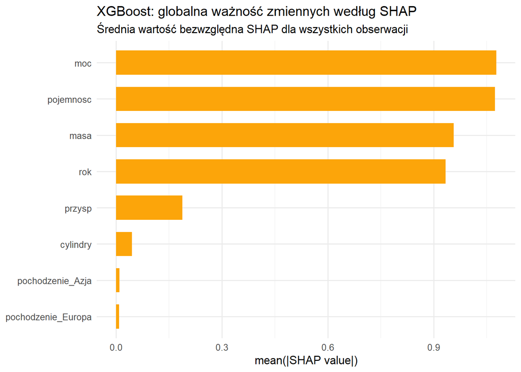

```r
sv_importance(
  shap_obj,
  kind = "bar",
  max_display = 10
) +
  labs(
    title = "XGBoost: globalna ważność zmiennych według SHAP",
    subtitle = "Średnia wartość bezwzględna SHAP dla wszystkich obserwacji"
  ) +
  theme_minimal()
```

Ten wykres pokazuje globalną ważność zmiennych mierzoną średnią wartością bezwzględną SHAP. Im większa średnia wartość `|SHAP|`, tym silniej dana zmienna wpływała na predykcje modelu w całym zbiorze treningowym. W przeciwieństwie do pojedynczego wykresu lokalnego, tutaj nie analizujemy jednego samochodu, lecz podsumowujemy wpływ zmiennych dla wszystkich obserwacji.

[figure not shown]

```r
sv_importance(
  shap_obj,
  kind = "beeswarm",
  max_display = 10
) +
  labs(
    title = "XGBoost: rozkład wartości SHAP",
    subtitle = "Każdy punkt oznacza wkład zmiennej dla jednej obserwacji"
  ) +
  theme_minimal()
```

Wykres typu *beeswarm* pokazuje nie tylko ważność zmiennych, ale także kierunek ich wpływu. Każdy punkt odpowiada jednej obserwacji. Położenie punktu na osi poziomej informuje, czy dana zmienna zwiększała, czy zmniejszała predykcję zużycia paliwa.Ten wykres jest bogatszy niż zwykła ważność zmiennych, ponieważ pokazuje również zróżnicowanie wpływu danej cechy między obserwacjami. Jeśli punkty są rozrzucone szeroko, oznacza to, że wpływ zmiennej silnie zależy od konkretnego samochodu i jego kombinacji cech.

# 16 Podsumowanie ścieżki analizy

Przeszliśmy pełną ścieżkę modelowania regresyjnego w ekosystemie **tidymodels** - od surowego pliku Excel do zinterpretowanego modelu z oceną na zbiorze testowym.

1. **Wprowadzenie do tidymodels** → zrozumienie filozofii frameworka.
2. **EDA** → rozkłady, korelacje, wykresy rozrzutu.
3. **Podział train / test** → `initial_split()` ze stratyfikacją.
4. **Preprocessing** → `recipe` z winsoryzacją, kodowaniem i standaryzacją (bez wycieku danych!).
5. **OLS** → model bazowy, współczynniki, diagnostyka reszt.
6. **LASSO** → regularyzacja L1, tuning penalty, selekcja zmiennych.
7. **CART** → drzewo regresyjne, tuning 3 hiperparametrów, wizualizacja drzewa.
8. **XGBoost** → gradient boosting, siatka space-filling, najlepszy RMSE.
9. **Porównanie** → metryki CV w jednej tabeli i na wykresie.
10. **Test** → `last_fit()` - otwarcie zbioru testowego raz.
11. **Interpretacja** → SHAP.

## 16.1 Kluczowe lekcje

- **tidymodels ujednolica proces** - zmiana modelu to zmiana jednej linijki (`set_engine()`), reszta pipeline’u nie wymaga zmian.
- **`recipe` chroni przed wyciekiem danych** - parametry transformacji są estymowane wyłącznie na zbiorze treningowym.
- **Współliniowość** to problem OLS, ale nie drzew ani XGBoost. LASSO może ograniczać problem współliniowości przez zmniejszanie lub zerowanie części współczynników, ale nie gwarantuje automatycznego usunięcia wszystkich redundantnych zmiennych.
- **Strojenie hiperparametrów** jest konieczne - domyślne ustawienia XGBoost mogą prowadzić do ekstremalnego przeuczenia.
- **Zbiór testowy otwieramy TYLKO RAZ** - wielokrotna ewaluacja to cichy wyciek danych.

# 17 Zadania do samodzielnej realizacji

Poniższe zadania są kontynuacją analizy przeprowadzonej w głównej części dokumentu. Wszystkie obiekty (`train_data`, `test_data`, `data_split`, `cv_folds`, `base_recipe`, `tree_recipe`, `reg_metrics`, `all_cv`, `xgb_fit`, `shap_obj`) są dostępne w środowisku.

## 17.1 Zadanie 1: Pełny pipeline tidymodels dla modelu KNN - zadanie główne

> **⚠️ Uwaga metodyczna:** W zadaniach ćwiczeniowych używamy `last_fit()`, aby przećwiczyć pełny schemat tidymodels. W praktycznym projekcie zbiór testowy powinien być otwarty tylko raz, po ostatecznym wyborze modelu. Wyniki z zadań traktujemy jako ćwiczenie składni, nie jako formalny proces selekcji.

## 17.3 Zadanie 1: Pełny pipeline tidymodels dla modelu KNN ⭐

W tym zadaniu zbudujemy od początku kompletny pipeline dla modelu KNN (*k-nearest neighbors*) w regresji. Model KNN przewiduje wartość zmiennej objaśnianej na podstawie najbardziej podobnych obserwacji ze zbioru uczącego.

Celem zadania jest przećwiczenie całej ścieżki tidymodels: specyfikacja recipe → definicja modelu → workflow → siatka hiperparametrów → tuning CV → wybór najlepszego modelu → ewaluacja na zbiorze testowym.

> **📖 Podpowiedź — model KNN**

> KNN (*k-nearest neighbors*) przewiduje wartość zmiennej objaśnianej jako (ważoną) średnią z $k$ najbliższych obserwacji w przestrzeni predyktorów. Kluczowe hiperparametry:

> | tidymodels | Znaczenie |
> | --- | --- |
> | `neighbors` | liczba sąsiadów $k$ |
> | `weight_func` | sposób ważenia sąsiadów (rectangular, triangular, epanechnikov…) |
> | `dist_power` | parametr odległości Minkowskiego (1 = Manhattan, 2 = euklidesowa) |

> Ponieważ KNN opiera się na **odległościach** między obserwacjami, standaryzacja zmiennych numerycznych jest tutaj szczególnie ważna — bez niej zmienna o dużym zakresie (np. `masa`) zdominuje obliczanie odległości.

> W tidymodels: `nearest_neighbor()` + `set_engine("kknn")`. Potrzebny pakiet: `kknn`.

### 17.3.1 Krok 1: Recipe

KNN wymaga standaryzacji, więc używamy recipe analogicznego do `base_recipe`. Winsoryzację stosujemy tylko do typowych zmiennych ilościowych ciągłych: `pojemnosc`, `moc`, `masa` i `przysp`. Nie winsoryzujemy tutaj zmiennej `rok`, bo ma ona charakter uporządkowanego wskaźnika czasu, ani zmiennej `cylindry`, która jest zmienną dyskretną o niewielu wartościach.

```r
#UZUPEŁNIJ!
### Krok 1: Recipe

knn_recipe <- recipe(zuzycie ~ ., data = train_data) %>%
  # TODO: dodaj winsoryzację zmiennych: pojemnosc, moc, masa, przysp
  step_winsorize_iqr(pojemnosc, moc, masa, przysp, multiplier = 1.5) %>%

  # TODO: zakoduj zmienne jakościowe jako zmienne zero-jedynkowe
  step_dummy(all_nominal_predictors(), one_hot = FALSE) %>%

  # TODO: usuń predyktory o zerowej wariancji
  step_zv(all_predictors()) %>%

  # TODO: wystandaryzuj predyktory numeryczne
  step_normalize(all_numeric_predictors())

knn_recipe
```

### 17.3.2 Krok 2: Specyfikacja modelu

```r
#UZUPEŁNIJ!
knn_spec <- nearest_neighbor(
  neighbors   = tune(),   # TODO: ustaw strojenie liczby sąsiadów
  weight_func = tune(),   # TODO: ustaw strojenie funkcji wag
  dist_power  = tune()    # TODO: ustaw strojenie potęgi odległości
) %>%
  set_engine("kknn") %>%   # TODO: silnik dla KNN
  set_mode("regression")         # TODO: tryb regresji
```

### 17.3.3 Krok 3: Workflow

```r
#UZUPEŁNIJ!

knn_wf <- workflow() %>%
  add_recipe(knn_recipe) %>%   # TODO: dodaj recipe dla KNN
  add_model(knn_spec)        # TODO: dodaj specyfikację modelu KNN

knn_wf
```

```
## ══ Workflow ════════════════════════════════════════════════════════════════════
## Preprocessor: Recipe
## Model: nearest_neighbor()
##
## ── Preprocessor ────────────────────────────────────────────────────────────────
## 4 Recipe Steps
##
## • step_winsorize_iqr()
## • step_dummy()
## • step_zv()
## • step_normalize()
##
## ── Model ───────────────────────────────────────────────────────────────────────
## K-Nearest Neighbor Model Specification (regression)
##
## Main Arguments:
##   neighbors = tune()
##   weight_func = tune()
##   dist_power = tune()
##
## Computational engine: kknn
```

### 17.3.4 Krok 4: Siatka hiperparametrów

W tym kroku tworzymy siatkę hiperparametrów dla KNN. Model będzie sprawdzał różne liczby sąsiadów, różne sposoby ważenia sąsiadów oraz różne definicje odległości.

Użyjemy zakresu `neighbors` od 3 do 25, trzech funkcji wag: `"rectangular"`, `"triangular"` i `"epanechnikov"` oraz dwóch wartości `dist_power`: 1 i 2. Wartość `dist_power = 1` odpowiada odległości Manhattan, a `dist_power = 2` odległości euklidesowej.

```r
#UZUPEŁNIJ!
knn_grid <- grid_regular(
  neighbors(range = c(3, 25)),   # TODO: zakres liczby sąsiadów, np. 3–25

  weight_func(values = c(
    "rectangular",   # TODO: prosty wariant wag
    "triangular",   # TODO: większa waga dla bliższych sąsiadów
    "epanechnikov"    # TODO: kolejny wariant wag malejących z odległością
  )),

  dist_power(range = c(1, 2)),  # TODO: 1 = Manhattan, 2 = euklidesowa

  levels = c(
    neighbors = 8,
    weight_func = 3,
    dist_power = 2
  )
)

cat("Kombinacji do przeszukania:", nrow(knn_grid), "\n")
```

```
## Kombinacji do przeszukania: 48
```

### 17.3.5 Krok 5: Tuning przez walidację krzyżową

W tym kroku uruchamiamy strojenie modelu KNN. Funkcja `tune_grid()` sprawdzi wszystkie kombinacje hiperparametrów z siatki `knn_grid` i oceni je w walidacji krzyżowej.

Argument `control_grid(save_pred = TRUE)` zapisuje predykcje z resamplingu. Dzięki temu później można nie tylko porównać metryki, ale też dokładniej analizować zachowanie modelu.

```r
#UZUPEŁNIJ!
knn_tune <- tune_grid(
  knn_wf,                  # TODO: workflow KNN,
  resamples = cv_folds,      # TODO: obiekt z walidacją krzyżową,
  grid      = knn_grid,      # TODO: siatka hiperparametrów,
  metrics   = reg_metrics,      # TODO: zestaw metryk regresyjnych,
  control   = control_grid(save_pred = TRUE)
)

collect_metrics(knn_tune) %>%
  filter(.metric == "rmse") %>%
  arrange(mean) %>%
  head(5) %>%
  kable(
    caption = "Top 5 konfiguracji KNN wg RMSE",
    digits = 4
  )
```

Top 5 konfiguracji KNN wg RMSE

| neighbors | weight_func | dist_power | .metric | .estimator | mean | n | std_err | .config |
| --- | --- | --- | --- | --- | --- | --- | --- | --- |
| 6 | triangular | 1 | rmse | standard | 1.221 | 15 | 0.0417 | pre0_mod11_post0 |
| 9 | triangular | 1 | rmse | standard | 1.224 | 15 | 0.0443 | pre0_mod17_post0 |
| 6 | epanechnikov | 1 | rmse | standard | 1.226 | 15 | 0.0433 | pre0_mod07_post0 |
| 6 | triangular | 2 | rmse | standard | 1.235 | 15 | 0.0463 | pre0_mod12_post0 |
| 9 | epanechnikov | 1 | rmse | standard | 1.240 | 15 | 0.0461 | pre0_mod13_post0 |

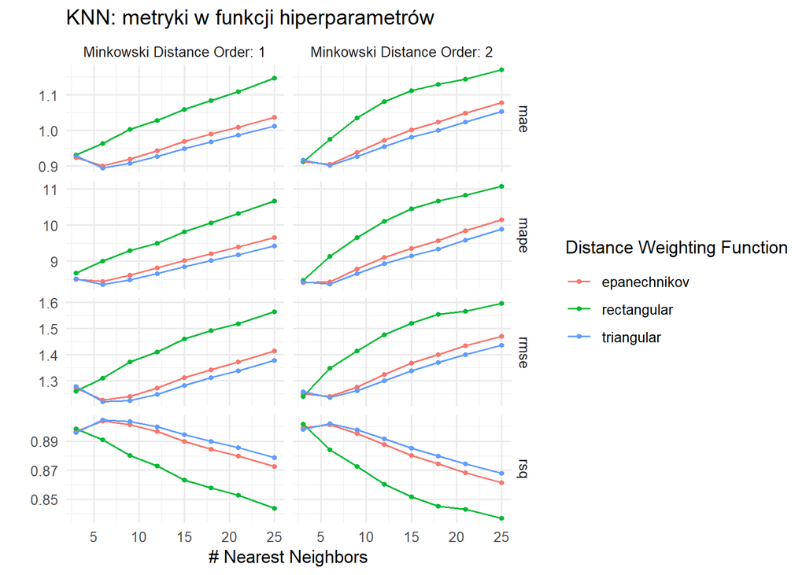

```r
autoplot(knn_tune) +
  labs(title = "KNN: metryki w funkcji hiperparametrów") +
  theme_minimal()
```

### 17.3.6 Krok 6: Wybór najlepszego modelu i finalizacja

Po zakończeniu strojenia wybieramy najlepszą konfigurację KNN według RMSE. Następnie `finalize_workflow()` podstawia wybrane hiperparametry do workflow, dzięki czemu otrzymujemy gotowy model do końcowego uczenia i oceny na zbiorze testowym.

```r
#UZUPEŁNIJ!
knn_best <- select_best(
  knn_tune,              # TODO: wyniki strojenia,
  metric = "rmse"   # TODO: metryka wyboru,
)

knn_best
```

| neighbors | weight_func | dist_power | .config |
| --- | --- | --- | --- |
| 6 | triangular | 1 | pre0_mod11_post0 |

```r
knn_final_wf <- finalize_workflow(
  knn_wf,      # TODO: workflow KNN,
  knn_best       # TODO: najlepsze hiperparametry,
)
```

### 17.3.7 Podgląd wyniku: najlepsza konfiguracja KNN

Po zakończeniu strojenia wybieramy taką kombinację hiperparametrów, która uzyskała najlepszy wynik w walidacji krzyżowej. W tym przykładzie kryterium wyboru jest najniższa wartość RMSE.

Ta tabela pokazuje, do jakiej konfiguracji powinien doprowadzić etap tuningu modelu KNN.

```r
knn_best %>%
  kable(
    caption = "Najlepsza konfiguracja hiperparametrów KNN według RMSE",
    digits = 4
  )
```

Najlepsza konfiguracja hiperparametrów KNN według RMSE

| neighbors | weight_func | dist_power | .config |
| --- | --- | --- | --- |
| 6 | triangular | 1 | pre0_mod11_post0 |

### 17.3.8 Krok 7: Ewaluacja na zbiorze testowym

W tym kroku oceniamy finalny model KNN na zbiorze testowym. Zbiór testowy był odłożony na początku analizy, więc traktujemy go jako końcową, bardziej niezależną ocenę jakości modelu.

```r
#UZUPEŁNIJ!

knn_last_fit <- last_fit(
  knn_final_wf,              # TODO: końcowy workflow KNN,
  split   = data_split,    # TODO: podział train/test,
  metrics = reg_metrics     # TODO: zestaw metryk regresyjnych,
)

collect_metrics(knn_last_fit) %>%
  kable(
    caption = "KNN — metryki na zbiorze testowym",
    digits = 4
  )
```

KNN — metryki na zbiorze testowym

| .metric | .estimator | .estimate | .config |
| --- | --- | --- | --- |
| rmse | standard | 1.2635 | pre0_mod0_post0 |
| rsq | standard | 0.8985 | pre0_mod0_post0 |
| mae | standard | 0.9745 | pre0_mod0_post0 |
| mape | standard | 9.2222 | pre0_mod0_post0 |

### 17.3.9 Podgląd wyniku: metryki testowe KNN w czytelnej tabeli

Wynik KNN warto obejrzeć nie tylko jako surowy output z `collect_metrics()`, ale też jako uporządkowaną tabelę. Dzięki temu w HTML-u od razu widać, jaki błąd uzyskał model na zbiorze testowym.

```r
knn_test_summary <- collect_metrics(knn_last_fit) %>%
  mutate(
    model = "KNN",
    interpretacja = case_when(
      .metric == "rmse" ~ "typowy większy błąd predykcji",
      .metric == "mae"  ~ "przeciętny błąd bezwzględny",
      .metric == "rsq"  ~ "udział wyjaśnionej zmienności",
      TRUE ~ ""
    )
  ) %>%
  dplyr::select(model, .metric, .estimate, interpretacja)

knn_test_summary %>%
  kable(
    caption = "KNN — podsumowanie metryk na zbiorze testowym",
    digits = 4
  )
```

KNN — podsumowanie metryk na zbiorze testowym

| model | .metric | .estimate | interpretacja |
| --- | --- | --- | --- |
| KNN | rmse | 1.2635 | typowy większy błąd predykcji |
| KNN | rsq | 0.8985 | udział wyjaśnionej zmienności |
| KNN | mae | 0.9745 | przeciętny błąd bezwzględny |
| KNN | mape | 9.2222 |  |

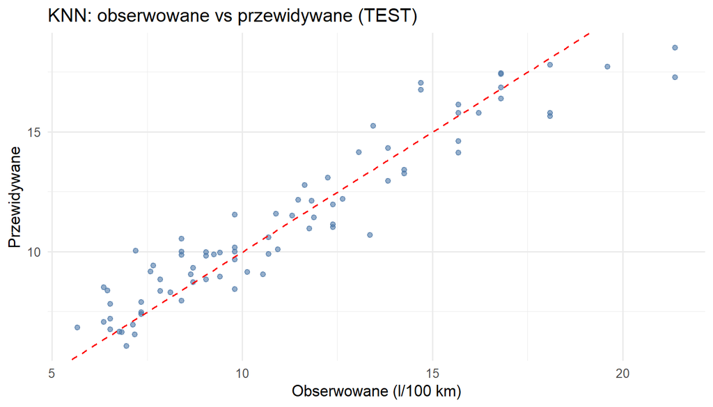

```r
knn_test_pred <- collect_predictions(knn_last_fit)

ggplot(knn_test_pred, aes(x = zuzycie, y = .pred)) +
  geom_point(alpha = 0.6, colour = "#4C78A8") +
  geom_abline(colour = "red", linetype = "dashed") +
  labs(title = "KNN: obserwowane vs przewidywane (TEST)",
       x = "Obserwowane (l/100 km)", y = "Przewidywane") +
  theme_minimal()
```

> **🔍 Pytanie do studenta:** Jak KNN wypada w porównaniu z modelami z głównej analizy? Dlaczego standaryzacja jest kluczowa dla KNN, a nieistotna dla drzew CART i XGBoost?